# Feature Optimization for Coffee Adulteration Detection Using Hyperspectral Imaging and Artificial Neural Networks: RFE and GA with SNV+SG+2nd Derivative

Author

Derick Malavi

## Introduction

This project leverages Artificial Neural Networks (ANN) to evaluate their effectiveness in distinguishing authentic coffee from adulterated samples using spectral data. By incorporating feature selection techniques such as Recursive Feature Elimination (RFE) and Genetic Algorithms (GA), the study aims to identify the most relevant spectral features, reducing dimensionality while maintaining model accuracy. ANN’s ability to model complex, non-linear relationships makes it ideal for analyzing high-dimensional spectroscopic datasets. The study evaluates the model’s performance in classifying pure and adulterated coffee across varying adulteration levels.

```r
# Load libraries
warning = FALSE
  suppressWarnings(suppressMessages({
  library(caret)
  library(GA)
  library(ggplot2)
  library(dplyr)
  library(readxl)
  library(readr)
  library(pls)
  library(janitor)
  library(ggthemes)
  library(class)
  library(MLmetrics)
  library(MLeval)
  library(themis)
  library(NeuralNetTools)
  library(ROSE)
  library(parallel)
  library(doParallel)
  library(foreach)
  library(pheatmap)
  library(mdatools)
  library(nnet)
  library(DMwR)
  library(e1071)
  library(knitr)
  library(pROC)
  library(gridExtra)
  library(FactoMineR)
  library(doSNOW)
  library(MASS)
  library(factoextra)
  library(kernlab)}))
```

## Prepare Data

```r
# Load data: snv_sg_2d spectra

hsi_snv_sg_2d <- read.csv("coffee_ground_snv_sg_2d.csv")

# Ensure we have the same number of dimensions and the range of our columns/covariates
dim(hsi_snv_sg_2d)
```

```
[1] 1469  229
```

```r
# Check a few column names
col_check <- colnames(hsi_snv_sg_2d[,c(1:6)])
col_check
```

```
[1] "sample_id"     "binary_class"  "three_class"   "adult_percent"
[5] "cal_val"       "X935.609985"
```

```r
# The spectral values start from column # 6-------> 229

# Convert the class to a factor
hsi_snv_sg_2d$binary_class <- as.factor(hsi_snv_sg_2d$binary_class)
```

## Get the X and y variables

```r
X <- hsi_snv_sg_2d[,c(6:229)]
y <- hsi_snv_sg_2d[,2]

class(y) #Ensure y (target variable) is a factor for classification
```

```
[1] "factor"
```

## Visualize X

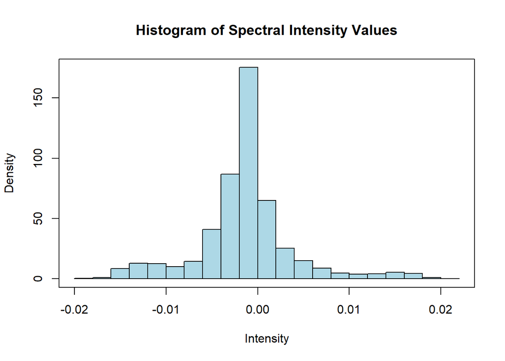

```r
hist(as.matrix(X), col = 'lightblue', freq = FALSE,
     main = 'Histogram of Spectral Intensity Values', xlab = 'Intensity'); box()
```

## Split the Data (Train_Test Split)

- We want to select features based on training data only to avoid any data leakage that could inflate model performance and make the model less generalizable to unseen data.

```r
# Subset samples for cross-validation and external validation (70/30)
# Record 1 under cal_val variable is for calibration while 2 will be for testing the model

sample<-hsi_snv_sg_2d$cal_val == 1

# Split to train and test sets
X_train <- X[sample,]
X_test <- X[!sample,]
y_train <-y[sample]
y_test <- y[!sample]

# Check length of the subsets for training and validation
dim(X_train)
```

```
[1] 1055  224
```

```r
dim(X_test)
```

```
[1] 414 224
```

```r
length(y_train)
```

```
[1] 1055
```

```r
length(y_test)
```

```
[1] 414
```

```r
# Merge the test and train data
train_data <- data.frame(X_train, binary_class = y_train)
test_data <- data.frame(X_test, binary_class = y_test)

# Check composition of the y variable for both train and test sets
table(train_data$binary_class)
```

```
 adulterated pure_arabica
        1007           48
```

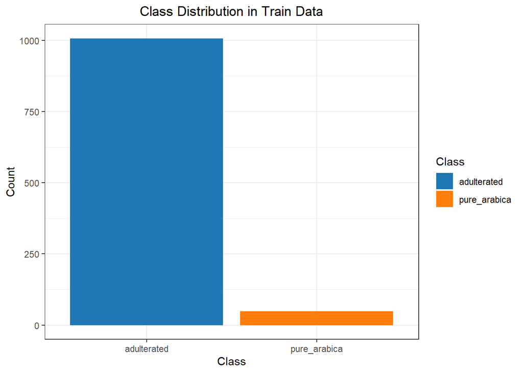

```r
# Create a bar plot for class distribution in train_data
train_data %>%
  count(binary_class) %>%
  ggplot(aes(x = binary_class, y = n, fill = binary_class)) +
  geom_bar(stat = "identity") +
  scale_fill_manual(values = c("#1f77b4", "#ff7f0e")) +  # Specify your custom colors here
  labs(title = "Class Distribution in Train Data",
       x = "Class",
       y = "Count",
       fill = "Class") +  # Ensure legend names are retained
  theme_bw() +
  theme(plot.title = element_text(hjust = 0.5))
```

## Balance the data using SMOTE

```r
# Due to data imbalance, we will use SMOTE to balance the data set

smote_data <- SMOTE(binary_class ~ ., data = train_data,
                    perc.over = 1900, perc.under = 100)

# Check new class distribution
table(smote_data$binary_class)
```

```
 adulterated pure_arabica
         912          960
```

```r
# Extract the X and y for the over-sampled data
X_train_smote <- smote_data[, -ncol(smote_data)]
y_train_smote <- smote_data$binary_class
```

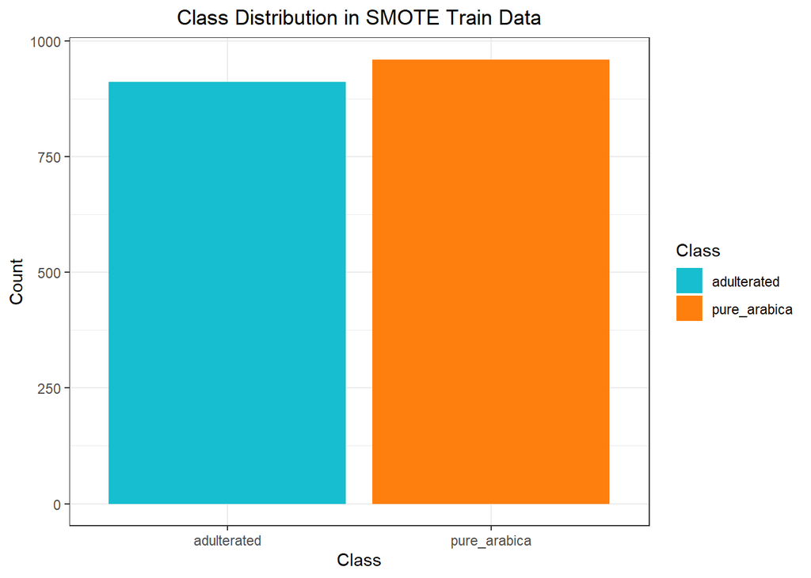

```r
# Visualize the balanced data

smote_data %>%
  count(binary_class) %>%
  ggplot(aes(x = binary_class, y = n, fill = binary_class)) +
  geom_bar(stat = "identity") +
  scale_fill_manual(values = c("#17becf", "#ff7f0e")) +  # Blue and Orange
  labs(title = "Class Distribution in SMOTE Train Data",
       x = "Class",
       y = "Count",
       fill = "Class") +
  theme_bw() +
  theme(plot.title = element_text(hjust = 0.5))
```

## Define the Fitness Function for GA

- This function evaluates subsets of features selected by GA using RFE with a Random Forest (RF) model.

```r
# Detect the number of cores
num_cores <- detectCores()
# Print the number of cores
print(paste("Number of cores available:", num_cores))
```

```
[1] "Number of cores available: 8"
```

```r
# Fitness Function
fitness_ga_rfe <- function(subset) {
  # Identify selected features based on the binary subset
  selected_features <- which(subset == 1)

  # Penalize empty subsets to avoid errors
  if (length(selected_features) == 0) return(Inf)

  # Subset the training feature matrix to selected features
  X_selected <- X_train[, selected_features]

  # Define control for rfe
  control <- rfeControl(functions = rfFuncs,  # Use Random Forest for rfe
                        method = "cv",       # Cross-validation
                        number = 10)         # 10-fold CV

  # Apply rfe to the selected subset of features
  rfe_result <- rfe(X_selected, y_train, rfeControl = control)

  # Return the negative accuracy as the fitness score (to maximize accuracy)
  return(-rfe_result$results$Accuracy[which.max(rfe_result$results$Accuracy)])
}
```

## Run the Genetic Algorithm

```r
# Set seed for reproducibility
set.seed(123)

num_features <- ncol(X_train) # Number of features
dataset_name <- "snv_sg_2d"   # Set the dataset name dynamically

# Define paths for the execution flag and GA result
flag_file <- paste0("ga_executed_flag_", dataset_name, ".RData")
result_file <- paste0("ga_result_", dataset_name, ".RData")

# Check if the result file exists
if (!file.exists(result_file)) {
  message("No result file found. Running the Genetic Algorithm (GA).")

  # Register cluster for caret to train the models in parallel
  cl <- makeCluster(6, type = "SOCK")
  suppressWarnings(suppressMessages(registerDoSNOW(cl)))

  # Register start time
  start_time <- Sys.time()

  # Run the Genetic Algorithm
  ga_result <- ga(
    type = "binary",
    fitness = fitness_ga_rfe,
    nBits = num_features,             # Number of features
    popSize = 20,                     # Population size
    maxiter = 50,                     # Maximum iterations
    run = 10,                         # Convergence stopping criterion
    names = colnames(train_data[, -ncol(train_data)]),  # Feature names
    pcrossover = 0.8,                 # Probability of crossover
    pmutation = 0.1,                  # Probability of mutation
    maxFitness = -0.9,                # Stop when fitness reaches target
    parallel = TRUE,                  # Enable parallel processing
    monitor = gaMonitor,              # Track progress
    seed = 123                        # Reproducibility
  )

  # Stop the cluster
  stopCluster(cl)

  # Register end time
  end_time <- Sys.time()
  print(paste('Time to run the GA model:', end_time - start_time))

  # Save the GA result and execution flag
  ga_executed <- TRUE
  save(ga_executed, ga_result, file = result_file)  # Save both flag and results

  message("GA execution completed and results saved.")

} else {
  # Load previously saved results
  message("Result file found. Loading saved GA results.")
  load(result_file)
  message(paste("GA already executed for dataset:", dataset_name))
}
```

```
Result file found. Loading saved GA results.
```

```
GA already executed for dataset: snv_sg_2d
```

## Visualization Plot

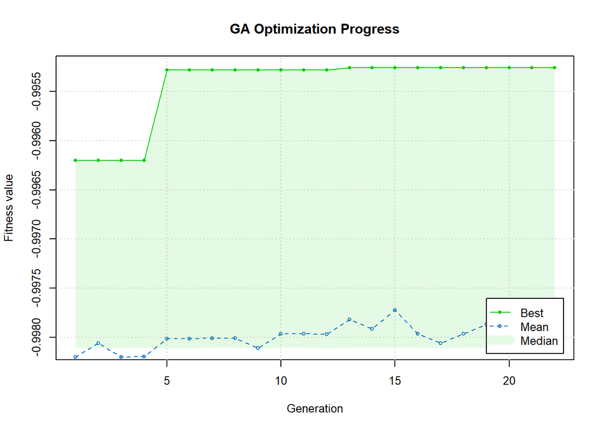

```r
par (cex = 0.8)
plot(ga_result, main = "GA Optimization Progress")
```

```r
par(cex = 1)
```

## Analyze GA results

```r
summary(ga_result)
```

```
── Genetic Algorithm ───────────────────

GA settings:
Type                  =  binary
Population size       =  20
Number of generations =  50
Elitism               =  1
Crossover probability =  0.8
Mutation probability  =  0.1

GA results:
Iterations             = 22
Fitness function value = -0.9952561
Solution =
     X935.609985 X939.059998 X942.52002 X945.97998 X949.429993 X952.890015
[1,]           0           1          1          0           1           1
     X956.349976 X959.809998 X963.27002 X966.72998  ...  X1716.650024
[1,]           0           1          1          0                  0
     X1720.22998
[1,]           0
```

## Post-Selection

```r
# Get the best feature subset
best_features <- which(ga_result@solution == 1)
selected_feature_names <- colnames(train_data)[best_features]
print(selected_feature_names)
```

```
  [1] "X939.059998"  "X942.52002"   "X949.429993"  "X952.890015"  "X959.809998"
  [6] "X963.27002"   "X970.190002"  "X973.650024"  "X987.51001"   "X997.900024"
 [11] "X1004.830017" "X1011.77002"  "X1015.23999"  "X1018.710022" "X1022.179993"
 [16] "X1025.650024" "X1029.119995" "X1032.589966" "X1046.47998"  "X1056.900024"
 [21] "X1060.380005" "X1063.849976" "X1070.810059" "X1081.23999"  "X1088.199951"
 [26] "X1098.650024" "X1112.579956" "X1116.069946" "X1119.550049" "X1123.040039"
 [31] "X1136.98999"  "X1140.469971" "X1143.959961" "X1157.930054" "X1164.910034"
 [36] "X1178.890015" "X1182.380005" "X1189.369995" "X1196.369995" "X1199.869995"
 [41] "X1210.369995" "X1213.869995" "X1224.369995" "X1227.869995" "X1234.880005"
 [46] "X1238.390015" "X1241.890015" "X1245.400024" "X1248.900024" "X1252.410034"
 [51] "X1262.930054" "X1266.439941" "X1269.949951" "X1273.459961" "X1276.969971"
 [56] "X1287.51001"  "X1291.02002"  "X1294.530029" "X1298.050049" "X1305.079956"
 [61] "X1308.589966" "X1315.619995" "X1319.140015" "X1329.699951" "X1333.219971"
 [66] "X1343.780029" "X1350.819946" "X1368.439941" "X1371.969971" "X1382.550049"
 [71] "X1386.079956" "X1393.140015" "X1403.72998"  "X1414.319946" "X1417.859985"
 [76] "X1421.390015" "X1424.920044" "X1435.530029" "X1442.599976" "X1456.76001"
 [81] "X1467.380005" "X1470.920044" "X1474.459961" "X1488.640015" "X1495.72998"
 [86] "X1509.910034" "X1513.459961" "X1520.560059" "X1527.660034" "X1531.209961"
 [91] "X1541.869995" "X1545.420044" "X1556.089966" "X1559.640015" "X1563.199951"
 [96] "X1570.310059" "X1577.430054" "X1580.98999"  "X1588.109985" "X1591.670044"
[101] "X1595.22998"  "X1602.349976" "X1609.47998"  "X1613.040039" "X1616.609985"
[106] "X1627.310059" "X1634.439941" "X1648.709961" "X1655.859985" "X1659.430054"
[111] "X1670.140015" "X1673.719971" "X1677.290039" "X1684.439941" "X1688.02002"
[116] "X1691.589966" "X1695.170044" "X1698.75"     "X1702.329956" "X1713.069946"
```

```r
print(paste('The number of selected variables are', length(selected_feature_names)))
```

```
[1] "The number of selected variables are 120"
```

```r
n_selected <- as.numeric(length(selected_feature_names))
```

## Create a Data frame with the Selected Features

```r
# Subset the training and test data using the selected features
X_train_selected <- X_train[, selected_feature_names, drop = FALSE]
X_test_selected <- X_test[, selected_feature_names, drop = FALSE]

# Keep y_train and y_test as-is
y_train_selected <- y_train
y_test_selected <- y_test


#Merge data_frame
train_merged <- cbind(X_train_selected, binary_class = y_train_selected)
test_merged <- cbind(X_test_selected, binary_class = y_test_selected)

dim(train_merged)
```

```
[1] 1055  121
```

```r
dim(test_merged)
```

```
[1] 414 121
```

```r
table(train_merged$binary_class)
```

```
 adulterated pure_arabica
        1007           48
```

```r
table(test_merged$binary_class)
```

```
 adulterated pure_arabica
         387           27
```

## Create a Data frame with the Selected Features for SMOTE Data

```r
X_train_selected_smote <- X_train_smote[,selected_feature_names, drop = FALSE]
X_test_selected_smote <- X_test[, selected_feature_names, drop = FALSE]

# Keep y_train and y_test as-is
y_train_selected_smote <- y_train
y_test_selected_smote <- y_test

#Merge data_frame
train_merged_smote <- cbind(X_train_selected_smote, binary_class = smote_data$binary_class)
test_merged_smote <- cbind(X_test_selected_smote, binary_class = y_test_selected_smote)

dim(train_merged_smote)
```

```
[1] 1872  121
```

```r
dim(test_merged_smote)
```

```
[1] 414 121
```

```r
table(train_merged_smote$binary_class)
```

```
 adulterated pure_arabica
         912          960
```

```r
table(test_merged_smote$binary_class)
```

```
 adulterated pure_arabica
         387           27
```

## Check correlations by HeatMaps

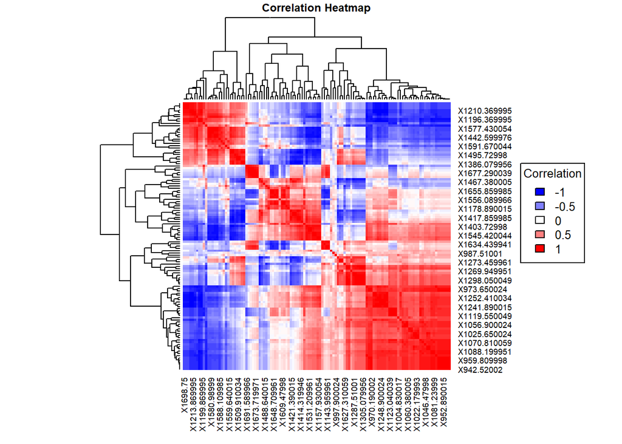

```r
# Calculate the correlation matrix

#Imbalanced Data

#Calculate correlations
corr <- cor(train_merged[, -(n_selected+1)])

# Create a heat map
par(cex.main = 0.6)
heatmap(corr, symm = TRUE,
        col = colorRampPalette(c("blue", "white", "red"))(50),
        main = "Correlation Heatmap")

# Add legend

legend("right",
       legend = seq(-1, 1, by = 0.5),  # Correlation range
       fill = colorRampPalette(c("blue", "white", "red"))(5),
       title = "Correlation", cex = 0.8)
```

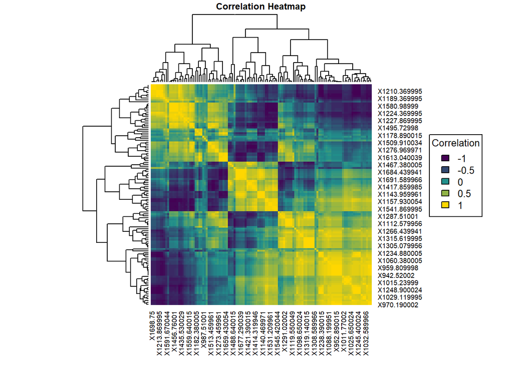

```r
# SMOTE Data
par(cex.main = 0.6)
corr <- cor(train_merged_smote[, -(n_selected+1)])
# Create heat map
heatmap(corr, symm = TRUE,
        col = colorRampPalette(c("#440154", "#21908C", "gold"))(50),
        main = 'Correlation Heatmap',cex.main = 0.6)

# Add legend
legend("right",
       legend = seq(-1, 1, by = 0.5),  # Correlation range
       fill = colorRampPalette(c("#440154", "#21908C", "gold"))(5),
       title = "Correlation",
       cex = 0.8)
```

- The correlation heat maps reveal that some variables remain highly correlated. To address this issue and mitigate multicollinearity, we will employ Principal Component Analysis (PCA). We will then proceed to train our models with features generated by PCA. This aims to speed up processing time.

## PreProcess by PCA, Centering and Scaling Data

```r
# Imbalanced Data
pca_Preprocess <- preProcess(train_merged, method = c("center", "scale", "pca"))
train_mergedPreprocessed <- predict(pca_Preprocess, train_merged) # train data
test_mergedPreprocessed <- predict(pca_Preprocess,test_merged) # apply on test data

# SMOTE Data
pca_Preprocess_smote <- preProcess(train_merged_smote,method = c("center", "scale", "pca"))
train_merged_smote_Preprocessed <- predict(pca_Preprocess_smote,train_merged_smote)
test_merged_smote_Preprocessed <- predict(pca_Preprocess_smote,test_merged_smote)

# Check dimensions of the preprocessed data to ensure consistency

dim(train_mergedPreprocessed)
```

```
[1] 1055   10
```

```r
dim(test_mergedPreprocessed)
```

```
[1] 414  10
```

```r
dim(train_merged_smote_Preprocessed)
```

```
[1] 1872    8
```

```r
dim(test_merged_smote_Preprocessed)
```

```
[1] 414   8
```

## Set Up Training Parameters

```r
# Set random seed for reproducibility

set.seed (123)

# Set up the training control(10 folds 10 times cross_validation)
control <- trainControl(method = "repeatedcv", number = 10, repeats = 10,
                        classProbs = TRUE, savePredictions = "final",
                        summaryFunction = multiClassSummary,
                        selectionFunction = 'oneSE', allowParallel = TRUE)

# One SE rule will be used to select simplest yet optimal model within the 'best model'
```

```r
#Set the metric as accuracy
metric<-"Accuracy"
```

```r
# Detect the number of cores
num_cores <- detectCores()
# Print the number of cores
print(paste("Number of cores available:", num_cores))
```

```
[1] "Number of cores available: 8"
```

```r
# Hyperparameter Tuning
# Set tune grid to find optimal value of size and decay on cross-validation
# Size is the number of number of units (neurons) in the hidden layer of the neural network
# Decay is the regularization parameter; adds penalty to the loss function

grid <- expand.grid(.size=seq(1,10, by =1),.decay=c(0,0.001,0.01,0.1,0.2,0.3,0.4,0.5))
```

## Train the Models

```r
#Register cluster for caret to train the models in parallel
set.seed(123)
cl<-makeCluster(6,type = "SOCK")
suppressWarnings(suppressMessages(
  registerDoSNOW(cl)))

# Start_time
start_time<-Sys.time()

#Train the model using cross-validation (10 folds, 10 times)
fit_nnet_snv_sg_2d<-train(binary_class ~., data = train_mergedPreprocessed,
                      method = 'nnet', tuneGrid = grid,
                      trControl = control, metric = 'Accuracy',
                      trace = FALSE, MaxNWts = 1000, maxit = 300) #unmodified data
#End_time
end_time<-Sys.time()
model_training_time<-end_time-start_time
stopCluster(cl) # Stop the parallel run cluster

print(model_training_time)
```

```
Time difference of 9.106081 mins
```

```r
print(fit_nnet_snv_sg_2d) # Model on imbalanced data
```

```
Neural Network

1055 samples
   9 predictor
   2 classes: 'adulterated', 'pure_arabica'

No pre-processing
Resampling: Cross-Validated (10 fold, repeated 10 times)
Summary of sample sizes: 949, 949, 949, 950, 949, 950, ...
Resampling results across tuning parameters:

  size  decay  logLoss       AUC        prAUC       Accuracy   Kappa
   1    0.000  0.0261800949  0.9935987  0.08426345  0.9915678  0.9115898
   1    0.001  0.0021019779  0.9997000  0.82191480  0.9995247  0.9954300
   1    0.010  0.0031180820  0.9997624  0.87587691  0.9995283  0.9954319
   1    0.100  0.0081700069  1.0000000  0.89003465  0.9990530  0.9874510
   1    0.200  0.0134783219  0.9997772  0.88834580  0.9985768  0.9819477
   1    0.300  0.0183265154  0.9994554  0.88590961  0.9974429  0.9692605
   1    0.400  0.0224867285  0.9992966  0.88450460  0.9969695  0.9649941
   1    0.500  0.0264332911  0.9987776  0.88078025  0.9967781  0.9630276
   2    0.000  0.0406130496  0.9918510  0.12503311  0.9945076  0.9422461
   2    0.001  0.0004937330  1.0000000  0.88968812  1.0000000  1.0000000
   2    0.010  0.0013288631  1.0000000  0.89003465  1.0000000  1.0000000
   2    0.100  0.0056695010  1.0000000  0.89003465  1.0000000  1.0000000
   2    0.200  0.0092170801  1.0000000  0.89003465  1.0000000  1.0000000
   2    0.300  0.0124338762  1.0000000  0.89003465  1.0000000  1.0000000
   2    0.400  0.0152595302  1.0000000  0.89003465  0.9999048  0.9985232
   2    0.500  0.0178776469  1.0000000  0.89003465  0.9998104  0.9973635
   3    0.000  0.0395159199  0.9941838  0.11527694  0.9956396  0.9491014
   3    0.001  0.0003745937  1.0000000  0.65077277  1.0000000  1.0000000
   3    0.010  0.0012064717  1.0000000  0.89003465  1.0000000  1.0000000
   3    0.100  0.0052565091  1.0000000  0.89003465  1.0000000  1.0000000
   3    0.200  0.0085536379  1.0000000  0.89003465  0.9999057  0.9988403
   3    0.300  0.0113482277  1.0000000  0.89003465  1.0000000  1.0000000
   3    0.400  0.0137112260  1.0000000  0.89003465  1.0000000  1.0000000
   3    0.500  0.0163859895  1.0000000  0.89003465  0.9999057  0.9988403
   4    0.000  0.0568592118  0.9925407  0.13546214  0.9952668  0.9494850
   4    0.001  0.0007267539  1.0000000  0.71258911  0.9997152  0.9971238
   4    0.010  0.0013273673  1.0000000  0.88909208  0.9997161  0.9971243
   4    0.100  0.0045955994  1.0000000  0.89003465  1.0000000  1.0000000
```

[output cut: 202 more lines]

```
  1.0000000  0.9993050  0.9538531       0.9996525
  1.0000000  0.9994040  0.9539475       0.9997020
  1.0000000  0.9996030  0.9541371       0.9998015
  1.0000000  1.0000000  0.9545153       1.0000000
  0.9988244  0.9979149  0.9525270       0.9864574
  1.0000000  0.9990069  0.9535692       0.9995035
  1.0000000  0.9990069  0.9535692       0.9995035
  1.0000000  0.9993040  0.9538522       0.9996520
  1.0000000  0.9991059  0.9536636       0.9995530
  1.0000000  0.9996030  0.9541371       0.9998015
  1.0000000  0.9995030  0.9540418       0.9997515
  1.0000000  0.9999010  0.9544210       0.9999505

Accuracy was used to select the optimal model using  the one SE rule.
The final values used for the model were size = 2 and decay = 0.3.
```

```r
#Register cluster for caret to train the models in parallel
set.seed(123)
cl<-makeCluster(6,type = "SOCK")
suppressWarnings(suppressMessages(
  registerDoSNOW(cl)))

fit_nnet_smote_snv_sg_2d<-train(binary_class~., data = train_merged_smote_Preprocessed,
                            method ='nnet', tuneGrid = grid,
                            trControl = control, metric = 'Accuracy',
                            trace = FALSE, MaxNWts = 1000, maxit = 300)# SMOTE data
#End_time
end_time<-Sys.time()
model_training_time<-end_time-start_time
stopCluster(cl) # Stop the parallel run cluster

print(model_training_time)
```

```
Time difference of 21.55324 mins
```

```r
print(fit_nnet_smote_snv_sg_2d)
```

```
Neural Network

1872 samples
   7 predictor
   2 classes: 'adulterated', 'pure_arabica'

No pre-processing
Resampling: Cross-Validated (10 fold, repeated 10 times)
Summary of sample sizes: 1684, 1685, 1685, 1685, 1685, 1685, ...
Resampling results across tuning parameters:

  size  decay  logLoss       AUC        prAUC       Accuracy   Kappa
   1    0.000  0.0324154192  0.9963179  0.01272600  0.9956727  0.9913328
   1    0.001  0.0138405670  0.9978168  0.43942784  0.9977031  0.9954014
   1    0.010  0.0093222719  0.9986770  0.76350433  0.9984520  0.9969010
   1    0.100  0.0087258262  0.9993670  0.88334112  0.9988255  0.9976488
   1    0.200  0.0123178321  0.9988714  0.90719869  0.9986645  0.9973262
   1    0.300  0.0151413078  0.9987819  0.92341921  0.9985044  0.9970056
   1    0.400  0.0185805016  0.9982879  0.93608873  0.9981849  0.9963662
   1    0.500  0.0198118644  0.9985679  0.94115759  0.9983451  0.9966871
   2    0.000  0.0237344738  0.9978533  0.01891856  0.9977560  0.9955062
   2    0.001  0.0018514184  0.9996967  0.90637722  0.9997326  0.9994646
   2    0.010  0.0016839726  0.9996966  0.96369623  0.9997867  0.9995729
   2    0.100  0.0026985030  1.0000000  0.98311465  0.9999465  0.9998929
   2    0.200  0.0046913031  1.0000000  0.98612767  0.9997864  0.9995724
   2    0.300  0.0064761520  0.9999840  0.98643708  0.9996797  0.9993589
   2    0.400  0.0082583197  0.9999668  0.98762892  0.9996794  0.9993582
   2    0.500  0.0091969169  1.0000000  0.98810031  0.9992525  0.9985035
   3    0.000  0.0216029732  0.9987821  0.03634508  0.9983963  0.9967882
   3    0.001  0.0005378444  0.9998901  0.96138500  0.9998930  0.9997859
   3    0.010  0.0003660539  1.0000000  0.98299998  1.0000000  1.0000000
   3    0.100  0.0019338744  1.0000000  0.98870471  1.0000000  1.0000000
   3    0.200  0.0032934082  1.0000000  0.98898003  0.9997864  0.9995723
   3    0.300  0.0047282511  1.0000000  0.98903438  0.9995196  0.9990382
   3    0.400  0.0058201904  1.0000000  0.98919922  0.9993591  0.9987171
   3    0.500  0.0067676027  1.0000000  0.98864977  0.9993591  0.9987171
   4    0.000  0.0114369792  0.9993779  0.02203385  0.9991450  0.9982881
   4    0.001  0.0001005711  1.0000000  0.98431806  1.0000000  1.0000000
   4    0.010  0.0012650037  0.9999159  0.98146063  0.9998930  0.9997859
   4    0.100  0.0016394862  1.0000000  0.98897944  1.0000000  1.0000000
```

[output cut: 202 more lines]

```
  1.0000000  1.0000000  0.4871772       1.0000000
  1.0000000  1.0000000  0.4871772       1.0000000
  1.0000000  0.9998901  0.4871237       0.9999451
  1.0000000  0.9997802  0.4870702       0.9998901
  0.9998901  0.9991245  0.4867502       0.9995101
  1.0000000  0.9995604  0.4869632       0.9997802
  1.0000000  1.0000000  0.4871772       1.0000000
  1.0000000  1.0000000  0.4871772       1.0000000
  1.0000000  0.9997802  0.4870702       0.9998901
  1.0000000  1.0000000  0.4871772       1.0000000
  1.0000000  0.9998901  0.4871237       0.9999451
  1.0000000  1.0000000  0.4871772       1.0000000

Accuracy was used to select the optimal model using  the one SE rule.
The final values used for the model were size = 3 and decay = 0.1.
```

## Save the models for future use

```r
saveRDS(fit_nnet_snv_sg_2d, "fit_nnet_snv_sg_2d.rds")
saveRDS(fit_nnet_smote_snv_sg_2d, "fit_nnet_smote_snv_sg_2d.rds")
```

## Display the cross-validation results

```r
print(paste('The optimal parametrers for training the nnet model are', round(as.numeric(fit_nnet_snv_sg_2d$bestTune$size),2),'neurons','and decay value of',fit_nnet_snv_sg_2d$bestTune$decay)) # unmodified data
```

```
[1] "The optimal parametrers for training the nnet model are 2 neurons and decay value of 0.3"
```

```r
print(paste('The optimal parametrers for training the nnet model are', round(as.numeric(fit_nnet_smote_snv_sg_2d$bestTune$size),2),'neurons','and decay value of',fit_nnet_smote_snv_sg_2d$bestTune$decay)) # SMOTE data
```

```
[1] "The optimal parametrers for training the nnet model are 3 neurons and decay value of 0.1"
```

```r
# Imbalanced data
kable(fit_nnet_snv_sg_2d$results,
      caption = "Cross-Validation Results on Imbalanced Data")
```

Cross-Validation Results on Imbalanced Data

| size | decay | logLoss | AUC | prAUC | Accuracy | Kappa | F1 | Sensitivity | Specificity | Pos_Pred_Value | Neg_Pred_Value | Precision | Recall | Detection_Rate | Balanced_Accuracy | logLossSD | AUCSD | prAUCSD | AccuracySD | KappaSD | F1SD | SensitivitySD | SpecificitySD | Pos_Pred_ValueSD | Neg_Pred_ValueSD | PrecisionSD | RecallSD | Detection_RateSD | Balanced_AccuracySD |
| --- | --- | --- | --- | --- | --- | --- | --- | --- | --- | --- | --- | --- | --- | --- | --- | --- | --- | --- | --- | --- | --- | --- | --- | --- | --- | --- | --- | --- | --- |
| 1 | 0.000 | 0.0261801 | 0.9935987 | 0.0842635 | 0.9915678 | 0.9115898 | 0.9955499 | 0.9918604 | 0.9860 | 0.9993296 | 0.8741542 | 0.9993296 | 0.9918604 | 0.9467480 | 0.9889302 | 0.0392834 | 0.0200352 | 0.1303985 | 0.0097098 | 0.1245263 | 0.0051172 | 0.0092964 | 0.1073275 | 0.0051244 | 0.1313647 | 0.0051244 | 0.0092964 | 0.0097876 | 0.0533278 |
| 1 | 0.001 | 0.0021020 | 0.9997000 | 0.8219148 | 0.9995247 | 0.9954300 | 0.9997482 | 0.9995020 | 1.0000 | 1.0000000 | 0.9925833 | 1.0000000 | 0.9995020 | 0.9540400 | 0.9997510 | 0.0069136 | 0.0030000 | 0.0284721 | 0.0031357 | 0.0285420 | 0.0016669 | 0.0032895 | 0.0000000 | 0.0000000 | 0.0452716 | 0.0000000 | 0.0032895 | 0.0048359 | 0.0016447 |
| 1 | 0.010 | 0.0031181 | 0.9997624 | 0.8758769 | 0.9995283 | 0.9954319 | 0.9997502 | 0.9996040 | 0.9980 | 0.9999020 | 0.9945833 | 0.9999020 | 0.9996040 | 0.9541380 | 0.9988020 | 0.0067138 | 0.0023762 | 0.0203637 | 0.0031087 | 0.0285278 | 0.0016516 | 0.0031215 | 0.0200000 | 0.0009804 | 0.0408828 | 0.0009804 | 0.0031215 | 0.0048531 | 0.0101013 |
| 1 | 0.100 | 0.0081700 | 1.0000000 | 0.8900347 | 0.9990530 | 0.9874510 | 0.9995069 | 1.0000000 | 0.9785 | 0.9990186 | 1.0000000 | 0.9990186 | 1.0000000 | 0.9545153 | 0.9892500 | 0.0033250 | 0.0000000 | 0.0100504 | 0.0028553 | 0.0381174 | 0.0014868 | 0.0000000 | 0.0652327 | 0.0029589 | 0.0000000 | 0.0029589 | 0.0000000 | 0.0036636 | 0.0326163 |
| 1 | 0.200 | 0.0134783 | 0.9997772 | 0.8883458 | 0.9985768 | 0.9819477 | 0.9992571 | 0.9997030 | 0.9740 | 0.9988216 | 0.9957143 | 0.9988216 | 0.9997030 | 0.9542296 | 0.9868515 | 0.0059522 | 0.0022277 | 0.0213171 | 0.0041341 | 0.0496883 | 0.0021655 | 0.0029703 | 0.0712373 | 0.0032073 | 0.0428571 | 0.0032073 | 0.0029703 | 0.0041617 | 0.0355948 |
| 1 | 0.300 | 0.0183265 | 0.9994554 | 0.8859096 | 0.9974429 | 0.9692605 | 0.9986616 | 0.9993069 | 0.9580 | 0.9980353 | 0.9902976 | 0.9980353 | 0.9993069 | 0.9538522 | 0.9786535 | 0.0073088 | 0.0034338 | 0.0279844 | 0.0053618 | 0.0602477 | 0.0028202 | 0.0042812 | 0.0849004 | 0.0039492 | 0.0588323 | 0.0039492 | 0.0042812 | 0.0052185 | 0.0423309 |
| 1 | 0.400 | 0.0224867 | 0.9992966 | 0.8845046 | 0.9969695 | 0.9649941 | 0.9984103 | 0.9987099 | 0.9600 | 0.9981334 | 0.9809167 | 0.9981334 | 0.9987099 | 0.9532835 | 0.9793550 | 0.0076445 | 0.0036302 | 0.0295346 | 0.0060028 | 0.0651254 | 0.0031625 | 0.0052090 | 0.0834847 | 0.0038736 | 0.0743118 | 0.0038736 | 0.0052090 | 0.0061168 | 0.0416311 |
| 1 | 0.500 | 0.0264333 | 0.9987776 | 0.8807803 | 0.9967781 | 0.9630276 | 0.9983093 | 0.9986089 | 0.9580 | 0.9980344 | 0.9797262 | 0.9980344 | 0.9986089 | 0.9531874 | 0.9783045 | 0.0079795 | 0.0049673 | 0.0380014 | 0.0062109 | 0.0667560 | 0.0032739 | 0.0054763 | 0.0849004 | 0.0039511 | 0.0775816 | 0.0039511 | 0.0054763 | 0.0063641 | 0.0423085 |
| 2 | 0.000 | 0.0406130 | 0.9918510 | 0.1250331 | 0.9945076 | 0.9422461 | 0.9971048 | 0.9955356 | 0.9735 | 0.9987215 | 0.9307143 | 0.9987215 | 0.9955356 | 0.9502565 | 0.9845178 | 0.1177900 | 0.0388372 | 0.1314613 | 0.0082073 | 0.0856018 | 0.0043372 | 0.0079014 | 0.0848216 | 0.0040943 | 0.1146679 | 0.0040943 | 0.0079014 | 0.0086592 | 0.0422449 |
| 2 | 0.001 | 0.0004937 | 1.0000000 | 0.8896881 | 1.0000000 | 1.0000000 | 1.0000000 | 1.0000000 | 1.0000 | 1.0000000 | 1.0000000 | 1.0000000 | 1.0000000 | 0.9545153 | 1.0000000 | 0.0008331 | 0.0000000 | 0.0101768 | 0.0000000 | 0.0000000 | 0.0000000 | 0.0000000 | 0.0000000 | 0.0000000 | 0.0000000 | 0.0000000 | 0.0000000 | 0.0036636 | 0.0000000 |
| 2 | 0.010 | 0.0013289 | 1.0000000 | 0.8900347 | 1.0000000 | 1.0000000 | 1.0000000 | 1.0000000 | 1.0000 | 1.0000000 | 1.0000000 | 1.0000000 | 1.0000000 | 0.9545153 | 1.0000000 | 0.0010274 | 0.0000000 | 0.0100504 | 0.0000000 | 0.0000000 | 0.0000000 | 0.0000000 | 0.0000000 | 0.0000000 | 0.0000000 | 0.0000000 | 0.0000000 | 0.0036636 | 0.0000000 |
| 2 | 0.100 | 0.0056695 | 1.0000000 | 0.8900347 | 1.0000000 | 1.0000000 | 1.0000000 | 1.0000000 | 1.0000 | 1.0000000 | 1.0000000 | 1.0000000 | 1.0000000 | 0.9545153 | 1.0000000 | 0.0021259 | 0.0000000 | 0.0100504 | 0.0000000 | 0.0000000 | 0.0000000 | 0.0000000 | 0.0000000 | 0.0000000 | 0.0000000 | 0.0000000 | 0.0000000 | 0.0036636 | 0.0000000 |
| 2 | 0.200 | 0.0092171 | 1.0000000 | 0.8900347 | 1.0000000 | 1.0000000 | 1.0000000 | 1.0000000 | 1.0000 | 1.0000000 | 1.0000000 | 1.0000000 | 1.0000000 | 0.9545153 | 1.0000000 | 0.0026598 | 0.0000000 | 0.0100504 | 0.0000000 | 0.0000000 | 0.0000000 | 0.0000000 | 0.0000000 | 0.0000000 | 0.0000000 | 0.0000000 | 0.0000000 | 0.0036636 | 0.0000000 |
| 2 | 0.300 | 0.0124339 | 1.0000000 | 0.8900347 | 1.0000000 | 1.0000000 | 1.0000000 | 1.0000000 | 1.0000 | 1.0000000 | 1.0000000 | 1.0000000 | 1.0000000 | 0.9545153 | 1.0000000 | 0.0029985 | 0.0000000 | 0.0100504 | 0.0000000 | 0.0000000 | 0.0000000 | 0.0000000 | 0.0000000 | 0.0000000 | 0.0000000 | 0.0000000 | 0.0000000 | 0.0036636 | 0.0000000 |
| 2 | 0.400 | 0.0152595 | 1.0000000 | 0.8900347 | 0.9999048 | 0.9985232 | 0.9999507 | 1.0000000 | 0.9975 | 0.9999020 | 1.0000000 | 0.9999020 | 1.0000000 | 0.9545153 | 0.9987500 | 0.0035624 | 0.0000000 | 0.0100504 | 0.0009524 | 0.0147679 | 0.0004926 | 0.0000000 | 0.0250000 | 0.0009804 | 0.0000000 | 0.0009804 | 0.0000000 | 0.0036636 | 0.0125000 |
| 2 | 0.500 | 0.0178776 | 1.0000000 | 0.8900347 | 0.9998104 | 0.9973635 | 0.9999015 | 1.0000000 | 0.9955 | 0.9998039 | 1.0000000 | 0.9998039 | 1.0000000 | 0.9545153 | 0.9977500 | 0.0035363 | 0.0000000 | 0.0100504 | 0.0013337 | 0.0186850 | 0.0006931 | 0.0000000 | 0.0318575 | 0.0013795 | 0.0000000 | 0.0013795 | 0.0000000 | 0.0036636 | 0.0159287 |
| 3 | 0.000 | 0.0395159 | 0.9941838 | 0.1152769 | 0.9956396 | 0.9491014 | 0.9977047 | 0.9968248 | 0.9690 | 0.9986301 | 0.9519721 | 0.9986301 | 0.9968248 | 0.9514884 | 0.9829124 | 0.0886075 | 0.0215784 | 0.1209181 | 0.0082494 | 0.1183741 | 0.0043559 | 0.0075794 | 0.1167273 | 0.0047804 | 0.0997468 | 0.0047804 | 0.0075794 | 0.0085445 | 0.0581460 |
| 3 | 0.001 | 0.0003746 | 1.0000000 | 0.6507728 | 1.0000000 | 1.0000000 | 1.0000000 | 1.0000000 | 1.0000 | 1.0000000 | 1.0000000 | 1.0000000 | 1.0000000 | 0.9545153 | 1.0000000 | 0.0005218 | 0.0000000 | 0.0583620 | 0.0000000 | 0.0000000 | 0.0000000 | 0.0000000 | 0.0000000 | 0.0000000 | 0.0000000 | 0.0000000 | 0.0000000 | 0.0036636 | 0.0000000 |
| 3 | 0.010 | 0.0012065 | 1.0000000 | 0.8900347 | 1.0000000 | 1.0000000 | 1.0000000 | 1.0000000 | 1.0000 | 1.0000000 | 1.0000000 | 1.0000000 | 1.0000000 | 0.9545153 | 1.0000000 | 0.0010017 | 0.0000000 | 0.0100504 | 0.0000000 | 0.0000000 | 0.0000000 | 0.0000000 | 0.0000000 | 0.0000000 | 0.0000000 | 0.0000000 | 0.0000000 | 0.0036636 | 0.0000000 |
| 3 | 0.100 | 0.0052565 | 1.0000000 | 0.8900347 | 1.0000000 | 1.0000000 | 1.0000000 | 1.0000000 | 1.0000 | 1.0000000 | 1.0000000 | 1.0000000 | 1.0000000 | 0.9545153 | 1.0000000 | 0.0023224 | 0.0000000 | 0.0100504 | 0.0000000 | 0.0000000 | 0.0000000 | 0.0000000 | 0.0000000 | 0.0000000 | 0.0000000 | 0.0000000 | 0.0000000 | 0.0036636 | 0.0000000 |
| 3 | 0.200 | 0.0085536 | 1.0000000 | 0.8900347 | 0.9999057 | 0.9988403 | 0.9999507 | 1.0000000 | 0.9980 | 0.9999020 | 1.0000000 | 0.9999020 | 1.0000000 | 0.9545153 | 0.9990000 | 0.0029015 | 0.0000000 | 0.0100504 | 0.0009434 | 0.0115974 | 0.0004926 | 0.0000000 | 0.0200000 | 0.0009804 | 0.0000000 | 0.0009804 | 0.0000000 | 0.0036636 | 0.0100000 |
| 3 | 0.300 | 0.0113482 | 1.0000000 | 0.8900347 | 1.0000000 | 1.0000000 | 1.0000000 | 1.0000000 | 1.0000 | 1.0000000 | 1.0000000 | 1.0000000 | 1.0000000 | 0.9545153 | 1.0000000 | 0.0029382 | 0.0000000 | 0.0100504 | 0.0000000 | 0.0000000 | 0.0000000 | 0.0000000 | 0.0000000 | 0.0000000 | 0.0000000 | 0.0000000 | 0.0000000 | 0.0036636 | 0.0000000 |
| 3 | 0.400 | 0.0137112 | 1.0000000 | 0.8900347 | 1.0000000 | 1.0000000 | 1.0000000 | 1.0000000 | 1.0000 | 1.0000000 | 1.0000000 | 1.0000000 | 1.0000000 | 0.9545153 | 1.0000000 | 0.0035743 | 0.0000000 | 0.0100504 | 0.0000000 | 0.0000000 | 0.0000000 | 0.0000000 | 0.0000000 | 0.0000000 | 0.0000000 | 0.0000000 | 0.0000000 | 0.0036636 | 0.0000000 |
| 3 | 0.500 | 0.0163860 | 1.0000000 | 0.8900347 | 0.9999057 | 0.9988403 | 0.9999507 | 1.0000000 | 0.9980 | 0.9999020 | 1.0000000 | 0.9999020 | 1.0000000 | 0.9545153 | 0.9990000 | 0.0037510 | 0.0000000 | 0.0100504 | 0.0009434 | 0.0115974 | 0.0004926 | 0.0000000 | 0.0200000 | 0.0009804 | 0.0000000 | 0.0009804 | 0.0000000 | 0.0036636 | 0.0100000 |
| 4 | 0.000 | 0.0568592 | 0.9925407 | 0.1354621 | 0.9952668 | 0.9494850 | 0.9975078 | 0.9967238 | 0.9655 | 0.9983265 | 0.9482341 | 0.9983265 | 0.9967238 | 0.9513904 | 0.9811119 | 0.1201452 | 0.0264274 | 0.1257985 | 0.0071812 | 0.0717712 | 0.0038006 | 0.0069223 | 0.0767704 | 0.0037164 | 0.0998638 | 0.0037164 | 0.0069223 | 0.0078375 | 0.0381879 |
| 4 | 0.001 | 0.0007268 | 1.0000000 | 0.7125891 | 0.9997152 | 0.9971238 | 0.9998497 | 0.9997010 | 1.0000 | 1.0000000 | 0.9950000 | 1.0000000 | 0.9997010 | 0.9542305 | 0.9998505 | 0.0018997 | 0.0000000 | 0.0745340 | 0.0016277 | 0.0164373 | 0.0008587 | 0.0017088 | 0.0000000 | 0.0000000 | 0.0285744 | 0.0000000 | 0.0017088 | 0.0041489 | 0.0008544 |
| 4 | 0.010 | 0.0013274 | 1.0000000 | 0.8890921 | 0.9997161 | 0.9971243 | 0.9998502 | 0.9997020 | 1.0000 | 1.0000000 | 0.9950000 | 1.0000000 | 0.9997020 | 0.9542314 | 0.9998510 | 0.0018437 | 0.0000000 | 0.0122606 | 0.0016226 | 0.0164344 | 0.0008558 | 0.0017032 | 0.0000000 | 0.0000000 | 0.0285744 | 0.0000000 | 0.0017032 | 0.0041361 | 0.0008516 |
| 4 | 0.100 | 0.0045956 | 1.0000000 | 0.8900347 | 1.0000000 | 1.0000000 | 1.0000000 | 1.0000000 | 1.0000 | 1.0000000 | 1.0000000 | 1.0000000 | 1.0000000 | 0.9545153 | 1.0000000 | 0.0022072 | 0.0000000 | 0.0100504 | 0.0000000 | 0.0000000 | 0.0000000 | 0.0000000 | 0.0000000 | 0.0000000 | 0.0000000 | 0.0000000 | 0.0000000 | 0.0036636 | 0.0000000 |
| 4 | 0.200 | 0.0075085 | 1.0000000 | 0.8900347 | 1.0000000 | 1.0000000 | 1.0000000 | 1.0000000 | 1.0000 | 1.0000000 | 1.0000000 | 1.0000000 | 1.0000000 | 0.9545153 | 1.0000000 | 0.0026499 | 0.0000000 | 0.0100504 | 0.0000000 | 0.0000000 | 0.0000000 | 0.0000000 | 0.0000000 | 0.0000000 | 0.0000000 | 0.0000000 | 0.0000000 | 0.0036636 | 0.0000000 |
| 4 | 0.300 | 0.0099720 | 1.0000000 | 0.8900347 | 1.0000000 | 1.0000000 | 1.0000000 | 1.0000000 | 1.0000 | 1.0000000 | 1.0000000 | 1.0000000 | 1.0000000 | 0.9545153 | 1.0000000 | 0.0029636 | 0.0000000 | 0.0100504 | 0.0000000 | 0.0000000 | 0.0000000 | 0.0000000 | 0.0000000 | 0.0000000 | 0.0000000 | 0.0000000 | 0.0000000 | 0.0036636 | 0.0000000 |
| 4 | 0.400 | 0.0120831 | 1.0000000 | 0.8900347 | 1.0000000 | 1.0000000 | 1.0000000 | 1.0000000 | 1.0000 | 1.0000000 | 1.0000000 | 1.0000000 | 1.0000000 | 0.9545153 | 1.0000000 | 0.0032947 | 0.0000000 | 0.0100504 | 0.0000000 | 0.0000000 | 0.0000000 | 0.0000000 | 0.0000000 | 0.0000000 | 0.0000000 | 0.0000000 | 0.0000000 | 0.0036636 | 0.0000000 |
| 4 | 0.500 | 0.0144130 | 1.0000000 | 0.8900347 | 1.0000000 | 1.0000000 | 1.0000000 | 1.0000000 | 1.0000 | 1.0000000 | 1.0000000 | 1.0000000 | 1.0000000 | 0.9545153 | 1.0000000 | 0.0034694 | 0.0000000 | 0.0100504 | 0.0000000 | 0.0000000 | 0.0000000 | 0.0000000 | 0.0000000 | 0.0000000 | 0.0000000 | 0.0000000 | 0.0000000 | 0.0036636 | 0.0000000 |
| 5 | 0.000 | 0.0501416 | 0.9948746 | 0.1480408 | 0.9958365 | 0.9543420 | 0.9978113 | 0.9971218 | 0.9695 | 0.9985274 | 0.9523690 | 0.9985274 | 0.9971218 | 0.9517714 | 0.9833109 | 0.0997200 | 0.0212075 | 0.1350894 | 0.0062106 | 0.0681593 | 0.0032688 | 0.0055126 | 0.0834529 | 0.0040370 | 0.0868819 | 0.0040370 | 0.0055126 | 0.0068910 | 0.0415278 |
| 5 | 0.001 | 0.0011531 | 1.0000000 | 0.7004891 | 0.9991482 | 0.9913728 | 0.9995507 | 0.9991059 | 1.0000 | 1.0000000 | 0.9850000 | 1.0000000 | 0.9991059 | 0.9536636 | 0.9995530 | 0.0031714 | 0.0000000 | 0.0549906 | 0.0027221 | 0.0275708 | 0.0014358 | 0.0028573 | 0.0000000 | 0.0000000 | 0.0479372 | 0.0000000 | 0.0028573 | 0.0048980 | 0.0014286 |
| 5 | 0.010 | 0.0013995 | 1.0000000 | 0.8556614 | 0.9995265 | 0.9952070 | 0.9997502 | 0.9995030 | 1.0000 | 1.0000000 | 0.9916667 | 1.0000000 | 0.9995030 | 0.9540418 | 0.9997515 | 0.0022237 | 0.0000000 | 0.0237308 | 0.0020743 | 0.0209976 | 0.0010942 | 0.0021774 | 0.0000000 | 0.0000000 | 0.0365072 | 0.0000000 | 0.0021774 | 0.0044169 | 0.0010887 |
| 5 | 0.100 | 0.0043575 | 1.0000000 | 0.8900347 | 0.9998095 | 0.9980822 | 0.9998995 | 0.9998000 | 1.0000 | 1.0000000 | 0.9966667 | 1.0000000 | 0.9998000 | 0.9543248 | 0.9999000 | 0.0024849 | 0.0000000 | 0.0100504 | 0.0013401 | 0.0134923 | 0.0007071 | 0.0014071 | 0.0000000 | 0.0000000 | 0.0234509 | 0.0000000 | 0.0014071 | 0.0040048 | 0.0007035 |
| 5 | 0.200 | 0.0067679 | 1.0000000 | 0.8900347 | 1.0000000 | 1.0000000 | 1.0000000 | 1.0000000 | 1.0000 | 1.0000000 | 1.0000000 | 1.0000000 | 1.0000000 | 0.9545153 | 1.0000000 | 0.0027334 | 0.0000000 | 0.0100504 | 0.0000000 | 0.0000000 | 0.0000000 | 0.0000000 | 0.0000000 | 0.0000000 | 0.0000000 | 0.0000000 | 0.0000000 | 0.0036636 | 0.0000000 |
| 5 | 0.300 | 0.0091356 | 1.0000000 | 0.8900347 | 1.0000000 | 1.0000000 | 1.0000000 | 1.0000000 | 1.0000 | 1.0000000 | 1.0000000 | 1.0000000 | 1.0000000 | 0.9545153 | 1.0000000 | 0.0028878 | 0.0000000 | 0.0100504 | 0.0000000 | 0.0000000 | 0.0000000 | 0.0000000 | 0.0000000 | 0.0000000 | 0.0000000 | 0.0000000 | 0.0000000 | 0.0036636 | 0.0000000 |
| 5 | 0.400 | 0.0111494 | 1.0000000 | 0.8900347 | 1.0000000 | 1.0000000 | 1.0000000 | 1.0000000 | 1.0000 | 1.0000000 | 1.0000000 | 1.0000000 | 1.0000000 | 0.9545153 | 1.0000000 | 0.0030308 | 0.0000000 | 0.0100504 | 0.0000000 | 0.0000000 | 0.0000000 | 0.0000000 | 0.0000000 | 0.0000000 | 0.0000000 | 0.0000000 | 0.0000000 | 0.0036636 | 0.0000000 |
| 5 | 0.500 | 0.0131918 | 1.0000000 | 0.8900347 | 1.0000000 | 1.0000000 | 1.0000000 | 1.0000000 | 1.0000 | 1.0000000 | 1.0000000 | 1.0000000 | 1.0000000 | 0.9545153 | 1.0000000 | 0.0032943 | 0.0000000 | 0.0100504 | 0.0000000 | 0.0000000 | 0.0000000 | 0.0000000 | 0.0000000 | 0.0000000 | 0.0000000 | 0.0000000 | 0.0000000 | 0.0036636 | 0.0000000 |
| 6 | 0.000 | 0.0283786 | 0.9983925 | 0.1362693 | 0.9960216 | 0.9566724 | 0.9979079 | 0.9970218 | 0.9750 | 0.9988206 | 0.9513810 | 0.9988206 | 0.9970218 | 0.9516734 | 0.9860109 | 0.0520095 | 0.0101003 | 0.1324354 | 0.0057420 | 0.0609816 | 0.0030261 | 0.0057330 | 0.0683500 | 0.0032099 | 0.0909856 | 0.0032099 | 0.0057330 | 0.0067071 | 0.0337423 |
| 6 | 0.001 | 0.0015561 | 1.0000000 | 0.6797144 | 0.9990539 | 0.9904144 | 0.9995010 | 0.9990069 | 1.0000 | 1.0000000 | 0.9833333 | 1.0000000 | 0.9990069 | 0.9535692 | 0.9995035 | 0.0044434 | 0.0000000 | 0.0469511 | 0.0028526 | 0.0289016 | 0.0015046 | 0.0029943 | 0.0000000 | 0.0000000 | 0.0502519 | 0.0000000 | 0.0029943 | 0.0050039 | 0.0014971 |
| 6 | 0.010 | 0.0014858 | 1.0000000 | 0.8429000 | 0.9993378 | 0.9932901 | 0.9996507 | 0.9993050 | 1.0000 | 1.0000000 | 0.9883333 | 1.0000000 | 0.9993050 | 0.9538531 | 0.9996525 | 0.0027915 | 0.0000000 | 0.0241263 | 0.0024258 | 0.0245803 | 0.0012795 | 0.0025462 | 0.0000000 | 0.0000000 | 0.0427387 | 0.0000000 | 0.0025462 | 0.0046619 | 0.0012731 |
| 6 | 0.100 | 0.0041871 | 1.0000000 | 0.8900347 | 0.9995256 | 0.9952065 | 0.9997497 | 0.9995020 | 1.0000 | 1.0000000 | 0.9916667 | 1.0000000 | 0.9995020 | 0.9540409 | 0.9997510 | 0.0026278 | 0.0000000 | 0.0100504 | 0.0020783 | 0.0209998 | 0.0010964 | 0.0021818 | 0.0000000 | 0.0000000 | 0.0365072 | 0.0000000 | 0.0021818 | 0.0044289 | 0.0010909 |
| 6 | 0.200 | 0.0063967 | 1.0000000 | 0.8900347 | 1.0000000 | 1.0000000 | 1.0000000 | 1.0000000 | 1.0000 | 1.0000000 | 1.0000000 | 1.0000000 | 1.0000000 | 0.9545153 | 1.0000000 | 0.0024853 | 0.0000000 | 0.0100504 | 0.0000000 | 0.0000000 | 0.0000000 | 0.0000000 | 0.0000000 | 0.0000000 | 0.0000000 | 0.0000000 | 0.0000000 | 0.0036636 | 0.0000000 |
| 6 | 0.300 | 0.0085768 | 1.0000000 | 0.8900347 | 1.0000000 | 1.0000000 | 1.0000000 | 1.0000000 | 1.0000 | 1.0000000 | 1.0000000 | 1.0000000 | 1.0000000 | 0.9545153 | 1.0000000 | 0.0028445 | 0.0000000 | 0.0100504 | 0.0000000 | 0.0000000 | 0.0000000 | 0.0000000 | 0.0000000 | 0.0000000 | 0.0000000 | 0.0000000 | 0.0000000 | 0.0036636 | 0.0000000 |
| 6 | 0.400 | 0.0103118 | 1.0000000 | 0.8900347 | 1.0000000 | 1.0000000 | 1.0000000 | 1.0000000 | 1.0000 | 1.0000000 | 1.0000000 | 1.0000000 | 1.0000000 | 0.9545153 | 1.0000000 | 0.0028670 | 0.0000000 | 0.0100504 | 0.0000000 | 0.0000000 | 0.0000000 | 0.0000000 | 0.0000000 | 0.0000000 | 0.0000000 | 0.0000000 | 0.0000000 | 0.0036636 | 0.0000000 |
| 6 | 0.500 | 0.0121507 | 1.0000000 | 0.8900347 | 1.0000000 | 1.0000000 | 1.0000000 | 1.0000000 | 1.0000 | 1.0000000 | 1.0000000 | 1.0000000 | 1.0000000 | 0.9545153 | 1.0000000 | 0.0032419 | 0.0000000 | 0.0100504 | 0.0000000 | 0.0000000 | 0.0000000 | 0.0000000 | 0.0000000 | 0.0000000 | 0.0000000 | 0.0000000 | 0.0000000 | 0.0036636 | 0.0000000 |
| 7 | 0.000 | 0.0492049 | 0.9940539 | 0.1433834 | 0.9959263 | 0.9547661 | 0.9978595 | 0.9972158 | 0.9685 | 0.9985284 | 0.9542381 | 0.9985284 | 0.9972158 | 0.9518612 | 0.9828579 | 0.1092547 | 0.0278199 | 0.1407090 | 0.0057514 | 0.0636252 | 0.0030260 | 0.0053043 | 0.0809211 | 0.0037816 | 0.0846465 | 0.0037816 | 0.0053043 | 0.0067451 | 0.0401223 |
| 7 | 0.001 | 0.0013414 | 1.0000000 | 0.6707550 | 0.9990539 | 0.9904144 | 0.9995010 | 0.9990069 | 1.0000 | 1.0000000 | 0.9833333 | 1.0000000 | 0.9990069 | 0.9535692 | 0.9995035 | 0.0038101 | 0.0000000 | 0.0455749 | 0.0028526 | 0.0289016 | 0.0015046 | 0.0029943 | 0.0000000 | 0.0000000 | 0.0502519 | 0.0000000 | 0.0029943 | 0.0050039 | 0.0014971 |
| 7 | 0.010 | 0.0014046 | 1.0000000 | 0.8338238 | 0.9992426 | 0.9923312 | 0.9996005 | 0.9992050 | 1.0000 | 1.0000000 | 0.9866667 | 1.0000000 | 0.9992050 | 0.9537579 | 0.9996025 | 0.0026108 | 0.0000000 | 0.0221325 | 0.0025815 | 0.0261370 | 0.0013616 | 0.0027098 | 0.0000000 | 0.0000000 | 0.0454433 | 0.0000000 | 0.0027098 | 0.0047879 | 0.0013549 |
| 7 | 0.100 | 0.0039544 | 1.0000000 | 0.8900347 | 0.9993378 | 0.9932901 | 0.9996507 | 0.9993050 | 1.0000 | 1.0000000 | 0.9883333 | 1.0000000 | 0.9993050 | 0.9538531 | 0.9996525 | 0.0027797 | 0.0000000 | 0.0100504 | 0.0024258 | 0.0245803 | 0.0012795 | 0.0025462 | 0.0000000 | 0.0000000 | 0.0427387 | 0.0000000 | 0.0025462 | 0.0046619 | 0.0012731 |
| 7 | 0.200 | 0.0061194 | 1.0000000 | 0.8900347 | 0.9995265 | 0.9952070 | 0.9997502 | 0.9995030 | 1.0000 | 1.0000000 | 0.9916667 | 1.0000000 | 0.9995030 | 0.9540418 | 0.9997515 | 0.0026539 | 0.0000000 | 0.0100504 | 0.0020743 | 0.0209976 | 0.0010942 | 0.0021774 | 0.0000000 | 0.0000000 | 0.0365072 | 0.0000000 | 0.0021774 | 0.0044169 | 0.0010887 |
| 7 | 0.300 | 0.0080268 | 1.0000000 | 0.8900347 | 0.9999048 | 0.9990411 | 0.9999497 | 0.9999000 | 1.0000 | 1.0000000 | 0.9983333 | 1.0000000 | 0.9999000 | 0.9544201 | 0.9999500 | 0.0028172 | 0.0000000 | 0.0100504 | 0.0009524 | 0.0095890 | 0.0005025 | 0.0010000 | 0.0000000 | 0.0000000 | 0.0166667 | 0.0000000 | 0.0010000 | 0.0038392 | 0.0005000 |
| 7 | 0.400 | 0.0098476 | 1.0000000 | 0.8900347 | 1.0000000 | 1.0000000 | 1.0000000 | 1.0000000 | 1.0000 | 1.0000000 | 1.0000000 | 1.0000000 | 1.0000000 | 0.9545153 | 1.0000000 | 0.0030123 | 0.0000000 | 0.0100504 | 0.0000000 | 0.0000000 | 0.0000000 | 0.0000000 | 0.0000000 | 0.0000000 | 0.0000000 | 0.0000000 | 0.0000000 | 0.0036636 | 0.0000000 |
| 7 | 0.500 | 0.0115465 | 1.0000000 | 0.8900347 | 1.0000000 | 1.0000000 | 1.0000000 | 1.0000000 | 1.0000 | 1.0000000 | 1.0000000 | 1.0000000 | 1.0000000 | 0.9545153 | 1.0000000 | 0.0032585 | 0.0000000 | 0.0100504 | 0.0000000 | 0.0000000 | 0.0000000 | 0.0000000 | 0.0000000 | 0.0000000 | 0.0000000 | 0.0000000 | 0.0000000 | 0.0036636 | 0.0000000 |
| 8 | 0.000 | 0.0478191 | 0.9964190 | 0.1549401 | 0.9956433 | 0.9498933 | 0.9977153 | 0.9976188 | 0.9545 | 0.9978363 | 0.9594286 | 0.9978363 | 0.9976188 | 0.9522440 | 0.9760594 | 0.0924952 | 0.0174135 | 0.1387502 | 0.0060823 | 0.0700941 | 0.0031923 | 0.0049069 | 0.0953714 | 0.0045402 | 0.0812545 | 0.0045402 | 0.0049069 | 0.0061842 | 0.0474914 |
| 8 | 0.001 | 0.0022468 | 1.0000000 | 0.6573030 | 0.9991482 | 0.9913728 | 0.9995507 | 0.9991059 | 1.0000 | 1.0000000 | 0.9850000 | 1.0000000 | 0.9991059 | 0.9536636 | 0.9995530 | 0.0069174 | 0.0000000 | 0.0474324 | 0.0027221 | 0.0275708 | 0.0014358 | 0.0028573 | 0.0000000 | 0.0000000 | 0.0479372 | 0.0000000 | 0.0028573 | 0.0048980 | 0.0014286 |
| 8 | 0.010 | 0.0017638 | 1.0000000 | 0.8260738 | 0.9991482 | 0.9913728 | 0.9995507 | 0.9991059 | 1.0000 | 1.0000000 | 0.9850000 | 1.0000000 | 0.9991059 | 0.9536636 | 0.9995530 | 0.0037215 | 0.0000000 | 0.0225948 | 0.0027221 | 0.0275708 | 0.0014358 | 0.0028573 | 0.0000000 | 0.0000000 | 0.0479372 | 0.0000000 | 0.0028573 | 0.0048980 | 0.0014286 |
| 8 | 0.100 | 0.0038567 | 1.0000000 | 0.8900347 | 0.9990539 | 0.9904144 | 0.9995010 | 0.9990069 | 1.0000 | 1.0000000 | 0.9833333 | 1.0000000 | 0.9990069 | 0.9535692 | 0.9995035 | 0.0028834 | 0.0000000 | 0.0100504 | 0.0028526 | 0.0289016 | 0.0015046 | 0.0029943 | 0.0000000 | 0.0000000 | 0.0502519 | 0.0000000 | 0.0029943 | 0.0050039 | 0.0014971 |
| 8 | 0.200 | 0.0058127 | 1.0000000 | 0.8900347 | 0.9994322 | 0.9942486 | 0.9997005 | 0.9994040 | 1.0000 | 1.0000000 | 0.9900000 | 1.0000000 | 0.9994040 | 0.9539475 | 0.9997020 | 0.0027401 | 0.0000000 | 0.0100504 | 0.0022589 | 0.0228796 | 0.0011915 | 0.0023711 | 0.0000000 | 0.0000000 | 0.0397805 | 0.0000000 | 0.0023711 | 0.0045421 | 0.0011856 |
| 8 | 0.300 | 0.0076347 | 1.0000000 | 0.8900347 | 0.9997161 | 0.9971243 | 0.9998502 | 0.9997020 | 1.0000 | 1.0000000 | 0.9950000 | 1.0000000 | 0.9997020 | 0.9542314 | 0.9998510 | 0.0028621 | 0.0000000 | 0.0100504 | 0.0016226 | 0.0164344 | 0.0008558 | 0.0017032 | 0.0000000 | 0.0000000 | 0.0285744 | 0.0000000 | 0.0017032 | 0.0041361 | 0.0008516 |
| 8 | 0.400 | 0.0093422 | 1.0000000 | 0.8900347 | 0.9997161 | 0.9971243 | 0.9998502 | 0.9997020 | 1.0000 | 1.0000000 | 0.9950000 | 1.0000000 | 0.9997020 | 0.9542314 | 0.9998510 | 0.0029194 | 0.0000000 | 0.0100504 | 0.0016226 | 0.0164344 | 0.0008558 | 0.0017032 | 0.0000000 | 0.0000000 | 0.0285744 | 0.0000000 | 0.0017032 | 0.0041361 | 0.0008516 |
| 8 | 0.500 | 0.0108018 | 1.0000000 | 0.8900347 | 1.0000000 | 1.0000000 | 1.0000000 | 1.0000000 | 1.0000 | 1.0000000 | 1.0000000 | 1.0000000 | 1.0000000 | 0.9545153 | 1.0000000 | 0.0031475 | 0.0000000 | 0.0100504 | 0.0000000 | 0.0000000 | 0.0000000 | 0.0000000 | 0.0000000 | 0.0000000 | 0.0000000 | 0.0000000 | 0.0000000 | 0.0036636 | 0.0000000 |
| 9 | 0.000 | 0.0330616 | 0.9950897 | 0.1429909 | 0.9963989 | 0.9620417 | 0.9981001 | 0.9975139 | 0.9730 | 0.9987197 | 0.9619978 | 0.9987197 | 0.9975139 | 0.9521451 | 0.9852569 | 0.0845537 | 0.0214072 | 0.1307728 | 0.0076081 | 0.0705147 | 0.0040618 | 0.0072797 | 0.0705032 | 0.0033289 | 0.0901416 | 0.0033289 | 0.0072797 | 0.0081868 | 0.0354193 |
| 9 | 0.001 | 0.0018299 | 1.0000000 | 0.6438460 | 0.9990539 | 0.9904144 | 0.9995010 | 0.9990069 | 1.0000 | 1.0000000 | 0.9833333 | 1.0000000 | 0.9990069 | 0.9535692 | 0.9995035 | 0.0053006 | 0.0000000 | 0.0484031 | 0.0028526 | 0.0289016 | 0.0015046 | 0.0029943 | 0.0000000 | 0.0000000 | 0.0502519 | 0.0000000 | 0.0029943 | 0.0050039 | 0.0014971 |
| 9 | 0.010 | 0.0017591 | 1.0000000 | 0.8171401 | 0.9990539 | 0.9904144 | 0.9995010 | 0.9990069 | 1.0000 | 1.0000000 | 0.9833333 | 1.0000000 | 0.9990069 | 0.9535692 | 0.9995035 | 0.0038712 | 0.0000000 | 0.0221558 | 0.0028526 | 0.0289016 | 0.0015046 | 0.0029943 | 0.0000000 | 0.0000000 | 0.0502519 | 0.0000000 | 0.0029943 | 0.0050039 | 0.0014971 |
| 9 | 0.100 | 0.0036251 | 1.0000000 | 0.8900347 | 0.9993378 | 0.9932901 | 0.9996507 | 0.9993050 | 1.0000 | 1.0000000 | 0.9883333 | 1.0000000 | 0.9993050 | 0.9538531 | 0.9996525 | 0.0026816 | 0.0000000 | 0.0100504 | 0.0024258 | 0.0245803 | 0.0012795 | 0.0025462 | 0.0000000 | 0.0000000 | 0.0427387 | 0.0000000 | 0.0025462 | 0.0046619 | 0.0012731 |
| 9 | 0.200 | 0.0055591 | 1.0000000 | 0.8900347 | 0.9993378 | 0.9932901 | 0.9996507 | 0.9993050 | 1.0000 | 1.0000000 | 0.9883333 | 1.0000000 | 0.9993050 | 0.9538531 | 0.9996525 | 0.0030597 | 0.0000000 | 0.0100504 | 0.0024258 | 0.0245803 | 0.0012795 | 0.0025462 | 0.0000000 | 0.0000000 | 0.0427387 | 0.0000000 | 0.0025462 | 0.0046619 | 0.0012731 |
| 9 | 0.300 | 0.0073376 | 1.0000000 | 0.8900347 | 0.9994322 | 0.9942486 | 0.9997005 | 0.9994040 | 1.0000 | 1.0000000 | 0.9900000 | 1.0000000 | 0.9994040 | 0.9539475 | 0.9997020 | 0.0028855 | 0.0000000 | 0.0100504 | 0.0022589 | 0.0228796 | 0.0011915 | 0.0023711 | 0.0000000 | 0.0000000 | 0.0397805 | 0.0000000 | 0.0023711 | 0.0045421 | 0.0011856 |
| 9 | 0.400 | 0.0089186 | 1.0000000 | 0.8900347 | 0.9996217 | 0.9961659 | 0.9998005 | 0.9996030 | 1.0000 | 1.0000000 | 0.9933333 | 1.0000000 | 0.9996030 | 0.9541371 | 0.9998015 | 0.0029425 | 0.0000000 | 0.0100504 | 0.0018624 | 0.0188780 | 0.0009823 | 0.0019549 | 0.0000000 | 0.0000000 | 0.0328244 | 0.0000000 | 0.0019549 | 0.0042737 | 0.0009774 |
| 9 | 0.500 | 0.0104418 | 1.0000000 | 0.8900347 | 1.0000000 | 1.0000000 | 1.0000000 | 1.0000000 | 1.0000 | 1.0000000 | 1.0000000 | 1.0000000 | 1.0000000 | 0.9545153 | 1.0000000 | 0.0031705 | 0.0000000 | 0.0100504 | 0.0000000 | 0.0000000 | 0.0000000 | 0.0000000 | 0.0000000 | 0.0000000 | 0.0000000 | 0.0000000 | 0.0000000 | 0.0036636 | 0.0000000 |
| 10 | 0.000 | 0.0368908 | 0.9939783 | 0.1255803 | 0.9968751 | 0.9649071 | 0.9983581 | 0.9979149 | 0.9750 | 0.9988244 | 0.9665357 | 0.9988244 | 0.9979149 | 0.9525270 | 0.9864574 | 0.1015152 | 0.0304909 | 0.1316283 | 0.0057168 | 0.0657577 | 0.0030085 | 0.0051443 | 0.0821123 | 0.0037478 | 0.0781890 | 0.0037478 | 0.0051443 | 0.0064237 | 0.0408154 |
| 10 | 0.001 | 0.0019554 | 1.0000000 | 0.6465119 | 0.9990539 | 0.9904144 | 0.9995010 | 0.9990069 | 1.0000 | 1.0000000 | 0.9833333 | 1.0000000 | 0.9990069 | 0.9535692 | 0.9995035 | 0.0057410 | 0.0000000 | 0.0485769 | 0.0028526 | 0.0289016 | 0.0015046 | 0.0029943 | 0.0000000 | 0.0000000 | 0.0502519 | 0.0000000 | 0.0029943 | 0.0050039 | 0.0014971 |
| 10 | 0.010 | 0.0018127 | 1.0000000 | 0.8124787 | 0.9990539 | 0.9904144 | 0.9995010 | 0.9990069 | 1.0000 | 1.0000000 | 0.9833333 | 1.0000000 | 0.9990069 | 0.9535692 | 0.9995035 | 0.0040149 | 0.0000000 | 0.0238719 | 0.0028526 | 0.0289016 | 0.0015046 | 0.0029943 | 0.0000000 | 0.0000000 | 0.0502519 | 0.0000000 | 0.0029943 | 0.0050039 | 0.0014971 |
| 10 | 0.100 | 0.0036290 | 1.0000000 | 0.8899356 | 0.9993369 | 0.9932897 | 0.9996502 | 0.9993040 | 1.0000 | 1.0000000 | 0.9883333 | 1.0000000 | 0.9993040 | 0.9538522 | 0.9996520 | 0.0029694 | 0.0000000 | 0.0100246 | 0.0024291 | 0.0245821 | 0.0012813 | 0.0025498 | 0.0000000 | 0.0000000 | 0.0427387 | 0.0000000 | 0.0025498 | 0.0046732 | 0.0012749 |
| 10 | 0.200 | 0.0052508 | 1.0000000 | 0.8900347 | 0.9991482 | 0.9913728 | 0.9995507 | 0.9991059 | 1.0000 | 1.0000000 | 0.9850000 | 1.0000000 | 0.9991059 | 0.9536636 | 0.9995530 | 0.0027974 | 0.0000000 | 0.0100504 | 0.0027221 | 0.0275708 | 0.0014358 | 0.0028573 | 0.0000000 | 0.0000000 | 0.0479372 | 0.0000000 | 0.0028573 | 0.0048980 | 0.0014286 |
| 10 | 0.300 | 0.0069720 | 1.0000000 | 0.8900347 | 0.9996217 | 0.9961659 | 0.9998005 | 0.9996030 | 1.0000 | 1.0000000 | 0.9933333 | 1.0000000 | 0.9996030 | 0.9541371 | 0.9998015 | 0.0029037 | 0.0000000 | 0.0100504 | 0.0018624 | 0.0188780 | 0.0009823 | 0.0019549 | 0.0000000 | 0.0000000 | 0.0328244 | 0.0000000 | 0.0019549 | 0.0042737 | 0.0009774 |
| 10 | 0.400 | 0.0086135 | 1.0000000 | 0.8900347 | 0.9995265 | 0.9952070 | 0.9997502 | 0.9995030 | 1.0000 | 1.0000000 | 0.9916667 | 1.0000000 | 0.9995030 | 0.9540418 | 0.9997515 | 0.0030070 | 0.0000000 | 0.0100504 | 0.0020743 | 0.0209976 | 0.0010942 | 0.0021774 | 0.0000000 | 0.0000000 | 0.0365072 | 0.0000000 | 0.0021774 | 0.0044169 | 0.0010887 |
| 10 | 0.500 | 0.0098307 | 1.0000000 | 0.8900347 | 0.9999057 | 0.9990416 | 0.9999502 | 0.9999010 | 1.0000 | 1.0000000 | 0.9983333 | 1.0000000 | 0.9999010 | 0.9544210 | 0.9999505 | 0.0032909 | 0.0000000 | 0.0100504 | 0.0009434 | 0.0095841 | 0.0004975 | 0.0009901 | 0.0000000 | 0.0000000 | 0.0166667 | 0.0000000 | 0.0009901 | 0.0038253 | 0.0004950 |

```r
# Select the best results row
selected_row <- fit_nnet_snv_sg_2d$results %>%
  filter(size==fit_nnet_snv_sg_2d$bestTune$size &
           decay ==fit_nnet_snv_sg_2d$bestTune$decay)

kable(selected_row)
```

| size | decay | logLoss | AUC | prAUC | Accuracy | Kappa | F1 | Sensitivity | Specificity | Pos_Pred_Value | Neg_Pred_Value | Precision | Recall | Detection_Rate | Balanced_Accuracy | logLossSD | AUCSD | prAUCSD | AccuracySD | KappaSD | F1SD | SensitivitySD | SpecificitySD | Pos_Pred_ValueSD | Neg_Pred_ValueSD | PrecisionSD | RecallSD | Detection_RateSD | Balanced_AccuracySD |
| --- | --- | --- | --- | --- | --- | --- | --- | --- | --- | --- | --- | --- | --- | --- | --- | --- | --- | --- | --- | --- | --- | --- | --- | --- | --- | --- | --- | --- | --- |
| 2 | 0.3 | 0.0124339 | 1 | 0.8900347 | 1 | 1 | 1 | 1 | 1 | 1 | 1 | 1 | 1 | 0.9545153 | 1 | 0.0029985 | 0 | 0.0100504 | 0 | 0 | 0 | 0 | 0 | 0 | 0 | 0 | 0 | 0.0036636 | 0 |

```r
# SMOTE Data
kable(fit_nnet_smote_snv_sg_2d$results,
      caption = "Cross-Validation Results on SMOTE Data")
```

Cross-Validation Results on SMOTE Data

| size | decay | logLoss | AUC | prAUC | Accuracy | Kappa | F1 | Sensitivity | Specificity | Pos_Pred_Value | Neg_Pred_Value | Precision | Recall | Detection_Rate | Balanced_Accuracy | logLossSD | AUCSD | prAUCSD | AccuracySD | KappaSD | F1SD | SensitivitySD | SpecificitySD | Pos_Pred_ValueSD | Neg_Pred_ValueSD | PrecisionSD | RecallSD | Detection_RateSD | Balanced_AccuracySD |
| --- | --- | --- | --- | --- | --- | --- | --- | --- | --- | --- | --- | --- | --- | --- | --- | --- | --- | --- | --- | --- | --- | --- | --- | --- | --- | --- | --- | --- | --- |
| 1 | 0.000 | 0.0324154 | 0.9963179 | 0.0127260 | 0.9956727 | 0.9913328 | 0.9954883 | 0.9911168 | 1.0000000 | 1.0000000 | 0.9917979 | 1.0000000 | 0.9911168 | 0.4828499 | 0.9955584 | 0.0548463 | 0.0063912 | 0.0518740 | 0.0068253 | 0.0136805 | 0.0072184 | 0.0140205 | 0.0000000 | 0.0000000 | 0.0126264 | 0.0000000 | 0.0140205 | 0.0069400 | 0.0070103 |
| 1 | 0.001 | 0.0138406 | 0.9978168 | 0.4394278 | 0.9977031 | 0.9954014 | 0.9976248 | 0.9952855 | 1.0000000 | 1.0000000 | 0.9955838 | 1.0000000 | 0.9952855 | 0.4848802 | 0.9976427 | 0.0192216 | 0.0040256 | 0.1528179 | 0.0034167 | 0.0068411 | 0.0035406 | 0.0070123 | 0.0000000 | 0.0000000 | 0.0065435 | 0.0000000 | 0.0070123 | 0.0035738 | 0.0035062 |
| 1 | 0.010 | 0.0093223 | 0.9986770 | 0.7635043 | 0.9984520 | 0.9969010 | 0.9984002 | 0.9968251 | 1.0000000 | 1.0000000 | 0.9970229 | 1.0000000 | 0.9968251 | 0.4856292 | 0.9984126 | 0.0164206 | 0.0034408 | 0.0555794 | 0.0030626 | 0.0061321 | 0.0031725 | 0.0062817 | 0.0000000 | 0.0000000 | 0.0058664 | 0.0000000 | 0.0062817 | 0.0030592 | 0.0031409 |
| 1 | 0.100 | 0.0087258 | 0.9993670 | 0.8833411 | 0.9988255 | 0.9976488 | 0.9987875 | 0.9975908 | 1.0000000 | 1.0000000 | 0.9977362 | 1.0000000 | 0.9975908 | 0.4860027 | 0.9987954 | 0.0114599 | 0.0019891 | 0.0308589 | 0.0024677 | 0.0049401 | 0.0025492 | 0.0050610 | 0.0000000 | 0.0000000 | 0.0047499 | 0.0000000 | 0.0050610 | 0.0025566 | 0.0025305 |
| 1 | 0.200 | 0.0123178 | 0.9988714 | 0.9071987 | 0.9986645 | 0.9973262 | 0.9986181 | 0.9972587 | 1.0000000 | 1.0000000 | 0.9974352 | 1.0000000 | 0.9972587 | 0.4858417 | 0.9986294 | 0.0129250 | 0.0031080 | 0.0291148 | 0.0029774 | 0.0059618 | 0.0030879 | 0.0061120 | 0.0000000 | 0.0000000 | 0.0056946 | 0.0000000 | 0.0061120 | 0.0031743 | 0.0030560 |
| 1 | 0.300 | 0.0151413 | 0.9987819 | 0.9234192 | 0.9985044 | 0.9970056 | 0.9984530 | 0.9969302 | 1.0000000 | 1.0000000 | 0.9971260 | 1.0000000 | 0.9969302 | 0.4856815 | 0.9984651 | 0.0124562 | 0.0031568 | 0.0265608 | 0.0030447 | 0.0060965 | 0.0031567 | 0.0062499 | 0.0000000 | 0.0000000 | 0.0058267 | 0.0000000 | 0.0062499 | 0.0032195 | 0.0031250 |
| 1 | 0.400 | 0.0185805 | 0.9982879 | 0.9360887 | 0.9981849 | 0.9963662 | 0.9981239 | 0.9962769 | 1.0000000 | 1.0000000 | 0.9965095 | 1.0000000 | 0.9962769 | 0.4853621 | 0.9981384 | 0.0129260 | 0.0041976 | 0.0268724 | 0.0032390 | 0.0064854 | 0.0033556 | 0.0066447 | 0.0000000 | 0.0000000 | 0.0062039 | 0.0000000 | 0.0066447 | 0.0032359 | 0.0033224 |
| 1 | 0.500 | 0.0198119 | 0.9985679 | 0.9411576 | 0.9983451 | 0.9966871 | 0.9982915 | 0.9966054 | 1.0000000 | 1.0000000 | 0.9968104 | 1.0000000 | 0.9966054 | 0.4855222 | 0.9983027 | 0.0113149 | 0.0034655 | 0.0265373 | 0.0028068 | 0.0056191 | 0.0028993 | 0.0057552 | 0.0000000 | 0.0000000 | 0.0054022 | 0.0000000 | 0.0057552 | 0.0028240 | 0.0028776 |
| 2 | 0.000 | 0.0237345 | 0.9978533 | 0.0189186 | 0.9977560 | 0.9955062 | 0.9976681 | 0.9953930 | 1.0000000 | 1.0000000 | 0.9957206 | 1.0000000 | 0.9953930 | 0.4849332 | 0.9976965 | 0.0611183 | 0.0047451 | 0.0316999 | 0.0046326 | 0.0092845 | 0.0048909 | 0.0095154 | 0.0000000 | 0.0000000 | 0.0086005 | 0.0000000 | 0.0095154 | 0.0048050 | 0.0047577 |
| 2 | 0.001 | 0.0018514 | 0.9996967 | 0.9063772 | 0.9997326 | 0.9994646 | 0.9997231 | 0.9994505 | 1.0000000 | 1.0000000 | 0.9994866 | 1.0000000 | 0.9994505 | 0.4869098 | 0.9997253 | 0.0087683 | 0.0022966 | 0.1110521 | 0.0013963 | 0.0027960 | 0.0014473 | 0.0028694 | 0.0000000 | 0.0000000 | 0.0026761 | 0.0000000 | 0.0028694 | 0.0018574 | 0.0014347 |
| 2 | 0.010 | 0.0016840 | 0.9996966 | 0.9636962 | 0.9997867 | 0.9995729 | 0.9997790 | 0.9995628 | 1.0000000 | 1.0000000 | 0.9995918 | 1.0000000 | 0.9995628 | 0.4869638 | 0.9997814 | 0.0085968 | 0.0022591 | 0.0293951 | 0.0015009 | 0.0030050 | 0.0015548 | 0.0030757 | 0.0000000 | 0.0000000 | 0.0028715 | 0.0000000 | 0.0030757 | 0.0017625 | 0.0015378 |
| 2 | 0.100 | 0.0026985 | 1.0000000 | 0.9831146 | 0.9999465 | 0.9998929 | 0.9999448 | 0.9998901 | 1.0000000 | 1.0000000 | 0.9998969 | 1.0000000 | 0.9998901 | 0.4871237 | 0.9999451 | 0.0013971 | 0.0000000 | 0.0104253 | 0.0005348 | 0.0010706 | 0.0005525 | 0.0010989 | 0.0000000 | 0.0000000 | 0.0010309 | 0.0000000 | 0.0010989 | 0.0012450 | 0.0005495 |
| 2 | 0.200 | 0.0046913 | 1.0000000 | 0.9861277 | 0.9997864 | 0.9995724 | 0.9997796 | 0.9995616 | 1.0000000 | 1.0000000 | 0.9995876 | 1.0000000 | 0.9995616 | 0.4869635 | 0.9997808 | 0.0018465 | 0.0000000 | 0.0072421 | 0.0010518 | 0.0021055 | 0.0010851 | 0.0021584 | 0.0000000 | 0.0000000 | 0.0020304 | 0.0000000 | 0.0021584 | 0.0015012 | 0.0010792 |
| 2 | 0.300 | 0.0064762 | 0.9999840 | 0.9864371 | 0.9996797 | 0.9993589 | 0.9996697 | 0.9993430 | 1.0000000 | 1.0000000 | 0.9993814 | 1.0000000 | 0.9993430 | 0.4868569 | 0.9996715 | 0.0033170 | 0.0001603 | 0.0076705 | 0.0012741 | 0.0025505 | 0.0013139 | 0.0026134 | 0.0000000 | 0.0000000 | 0.0024607 | 0.0000000 | 0.0026134 | 0.0016109 | 0.0013067 |
| 2 | 0.400 | 0.0082583 | 0.9999668 | 0.9876289 | 0.9996794 | 0.9993582 | 0.9996691 | 0.9993419 | 1.0000000 | 1.0000000 | 0.9993814 | 1.0000000 | 0.9993419 | 0.4868566 | 0.9996709 | 0.0036559 | 0.0003320 | 0.0057154 | 0.0012753 | 0.0025529 | 0.0013163 | 0.0026182 | 0.0000000 | 0.0000000 | 0.0024607 | 0.0000000 | 0.0026182 | 0.0017005 | 0.0013091 |
| 2 | 0.500 | 0.0091969 | 1.0000000 | 0.9881003 | 0.9992525 | 0.9985035 | 0.9992277 | 0.9984663 | 1.0000000 | 1.0000000 | 0.9985609 | 1.0000000 | 0.9984663 | 0.4864296 | 0.9992332 | 0.0026875 | 0.0000000 | 0.0031846 | 0.0021486 | 0.0043016 | 0.0022213 | 0.0044070 | 0.0000000 | 0.0000000 | 0.0041301 | 0.0000000 | 0.0044070 | 0.0023394 | 0.0022035 |
| 3 | 0.000 | 0.0216030 | 0.9987821 | 0.0363451 | 0.9983963 | 0.9967882 | 0.9983313 | 0.9967057 | 1.0000000 | 1.0000000 | 0.9969480 | 1.0000000 | 0.9967057 | 0.4855734 | 0.9983528 | 0.0670077 | 0.0031418 | 0.0840970 | 0.0041971 | 0.0084103 | 0.0044143 | 0.0086238 | 0.0000000 | 0.0000000 | 0.0078411 | 0.0000000 | 0.0086238 | 0.0044725 | 0.0043119 |
| 3 | 0.001 | 0.0005378 | 0.9998901 | 0.9613850 | 0.9998930 | 0.9997859 | 0.9998895 | 0.9997802 | 1.0000000 | 1.0000000 | 0.9997938 | 1.0000000 | 0.9997802 | 0.4870702 | 0.9998901 | 0.0034531 | 0.0010989 | 0.0806557 | 0.0007524 | 0.0015064 | 0.0007774 | 0.0015462 | 0.0000000 | 0.0000000 | 0.0014506 | 0.0000000 | 0.0015462 | 0.0013745 | 0.0007731 |
| 3 | 0.010 | 0.0003661 | 1.0000000 | 0.9830000 | 1.0000000 | 1.0000000 | 1.0000000 | 1.0000000 | 1.0000000 | 1.0000000 | 1.0000000 | 1.0000000 | 1.0000000 | 0.4871772 | 1.0000000 | 0.0003165 | 0.0000000 | 0.0138732 | 0.0000000 | 0.0000000 | 0.0000000 | 0.0000000 | 0.0000000 | 0.0000000 | 0.0000000 | 0.0000000 | 0.0000000 | 0.0010978 | 0.0000000 |
| 3 | 0.100 | 0.0019339 | 1.0000000 | 0.9887047 | 1.0000000 | 1.0000000 | 1.0000000 | 1.0000000 | 1.0000000 | 1.0000000 | 1.0000000 | 1.0000000 | 1.0000000 | 0.4871772 | 1.0000000 | 0.0011322 | 0.0000000 | 0.0021978 | 0.0000000 | 0.0000000 | 0.0000000 | 0.0000000 | 0.0000000 | 0.0000000 | 0.0000000 | 0.0000000 | 0.0000000 | 0.0010978 | 0.0000000 |
| 3 | 0.200 | 0.0032934 | 1.0000000 | 0.9889800 | 0.9997864 | 0.9995723 | 0.9997790 | 0.9995616 | 1.0000000 | 1.0000000 | 0.9995897 | 1.0000000 | 0.9995616 | 0.4869635 | 0.9997808 | 0.0022511 | 0.0000000 | 0.0013098 | 0.0012977 | 0.0025983 | 0.0013445 | 0.0026642 | 0.0000000 | 0.0000000 | 0.0024868 | 0.0000000 | 0.0026642 | 0.0016827 | 0.0013321 |
| 3 | 0.300 | 0.0047283 | 1.0000000 | 0.9890344 | 0.9995196 | 0.9990382 | 0.9995040 | 0.9990146 | 1.0000000 | 1.0000000 | 0.9990743 | 1.0000000 | 0.9990146 | 0.4866967 | 0.9995073 | 0.0022216 | 0.0000000 | 0.0014372 | 0.0017114 | 0.0034260 | 0.0017672 | 0.0035078 | 0.0000000 | 0.0000000 | 0.0032949 | 0.0000000 | 0.0035078 | 0.0019452 | 0.0017539 |
| 3 | 0.400 | 0.0058202 | 1.0000000 | 0.9891992 | 0.9993591 | 0.9987171 | 0.9993388 | 0.9986849 | 1.0000000 | 1.0000000 | 0.9987629 | 1.0000000 | 0.9986849 | 0.4865363 | 0.9993425 | 0.0024355 | 0.0000000 | 0.0007752 | 0.0017442 | 0.0034916 | 0.0017995 | 0.0035793 | 0.0000000 | 0.0000000 | 0.0033670 | 0.0000000 | 0.0035793 | 0.0020184 | 0.0017896 |
| 3 | 0.500 | 0.0067676 | 1.0000000 | 0.9886498 | 0.9993591 | 0.9987171 | 0.9993388 | 0.9986849 | 1.0000000 | 1.0000000 | 0.9987629 | 1.0000000 | 0.9986849 | 0.4865363 | 0.9993425 | 0.0026787 | 0.0000000 | 0.0019613 | 0.0017442 | 0.0034916 | 0.0017995 | 0.0035793 | 0.0000000 | 0.0000000 | 0.0033670 | 0.0000000 | 0.0035793 | 0.0020184 | 0.0017896 |
| 4 | 0.000 | 0.0114370 | 0.9993779 | 0.0220339 | 0.9991450 | 0.9982881 | 0.9991154 | 0.9982441 | 1.0000000 | 1.0000000 | 0.9983568 | 1.0000000 | 0.9982441 | 0.4863221 | 0.9991221 | 0.0378412 | 0.0019600 | 0.0373159 | 0.0023686 | 0.0047430 | 0.0024580 | 0.0048650 | 0.0000000 | 0.0000000 | 0.0045281 | 0.0000000 | 0.0048650 | 0.0026780 | 0.0024325 |
| 4 | 0.001 | 0.0001006 | 1.0000000 | 0.9843181 | 1.0000000 | 1.0000000 | 1.0000000 | 1.0000000 | 1.0000000 | 1.0000000 | 1.0000000 | 1.0000000 | 1.0000000 | 0.4871772 | 1.0000000 | 0.0001793 | 0.0000000 | 0.0091347 | 0.0000000 | 0.0000000 | 0.0000000 | 0.0000000 | 0.0000000 | 0.0000000 | 0.0000000 | 0.0000000 | 0.0000000 | 0.0010978 | 0.0000000 |
| 4 | 0.010 | 0.0012650 | 0.9999159 | 0.9814606 | 0.9998930 | 0.9997859 | 0.9998901 | 0.9998901 | 0.9998958 | 0.9998901 | 0.9998958 | 0.9998901 | 0.9998901 | 0.4871237 | 0.9998930 | 0.0093354 | 0.0008413 | 0.0724286 | 0.0010695 | 0.0021406 | 0.0010989 | 0.0010989 | 0.0010417 | 0.0010989 | 0.0010417 | 0.0010989 | 0.0010989 | 0.0012450 | 0.0010703 |
| 4 | 0.100 | 0.0016395 | 1.0000000 | 0.9889794 | 1.0000000 | 1.0000000 | 1.0000000 | 1.0000000 | 1.0000000 | 1.0000000 | 1.0000000 | 1.0000000 | 1.0000000 | 0.4871772 | 1.0000000 | 0.0009872 | 0.0000000 | 0.0013147 | 0.0000000 | 0.0000000 | 0.0000000 | 0.0000000 | 0.0000000 | 0.0000000 | 0.0000000 | 0.0000000 | 0.0000000 | 0.0010978 | 0.0000000 |
| 4 | 0.200 | 0.0029070 | 1.0000000 | 0.9888695 | 0.9997861 | 0.9995716 | 0.9997778 | 0.9995604 | 1.0000000 | 1.0000000 | 0.9995918 | 1.0000000 | 0.9995604 | 0.4869632 | 0.9997802 | 0.0021363 | 0.0000000 | 0.0015019 | 0.0015049 | 0.0030136 | 0.0015634 | 0.0030924 | 0.0000000 | 0.0000000 | 0.0028715 | 0.0000000 | 0.0030924 | 0.0019250 | 0.0015462 |
| 4 | 0.300 | 0.0037327 | 1.0000000 | 0.9888695 | 0.9999468 | 0.9998935 | 0.9999454 | 0.9998913 | 1.0000000 | 1.0000000 | 0.9998969 | 1.0000000 | 0.9998913 | 0.4871240 | 0.9999457 | 0.0015405 | 0.0000000 | 0.0016928 | 0.0005319 | 0.0010646 | 0.0005464 | 0.0010870 | 0.0000000 | 0.0000000 | 0.0010309 | 0.0000000 | 0.0010870 | 0.0011195 | 0.0005435 |
| 4 | 0.400 | 0.0048300 | 1.0000000 | 0.9888695 | 0.9997867 | 0.9995729 | 0.9997796 | 0.9995628 | 1.0000000 | 1.0000000 | 0.9995897 | 1.0000000 | 0.9995628 | 0.4869638 | 0.9997814 | 0.0021692 | 0.0000000 | 0.0016928 | 0.0012942 | 0.0025908 | 0.0013369 | 0.0026496 | 0.0000000 | 0.0000000 | 0.0024868 | 0.0000000 | 0.0026496 | 0.0015901 | 0.0013248 |
| 4 | 0.500 | 0.0057692 | 1.0000000 | 0.9889245 | 0.9994123 | 0.9988233 | 0.9993910 | 0.9987936 | 1.0000000 | 1.0000000 | 0.9988743 | 1.0000000 | 0.9987936 | 0.4865895 | 0.9993968 | 0.0029572 | 0.0000000 | 0.0016140 | 0.0022657 | 0.0045373 | 0.0023550 | 0.0046533 | 0.0000000 | 0.0000000 | 0.0043179 | 0.0000000 | 0.0046533 | 0.0025298 | 0.0023266 |
| 5 | 0.000 | 0.0049087 | 0.9999176 | 0.0264464 | 0.9991984 | 0.9983987 | 0.9992041 | 0.9994529 | 0.9989583 | 0.9990099 | 0.9994845 | 0.9990099 | 0.9994529 | 0.4869103 | 0.9992056 | 0.0250819 | 0.0006090 | 0.0723093 | 0.0054475 | 0.0108729 | 0.0053188 | 0.0023966 | 0.0104167 | 0.0099010 | 0.0022582 | 0.0099010 | 0.0023966 | 0.0015096 | 0.0053174 |
| 5 | 0.001 | 0.0001103 | 1.0000000 | 0.9877706 | 1.0000000 | 1.0000000 | 1.0000000 | 1.0000000 | 1.0000000 | 1.0000000 | 1.0000000 | 1.0000000 | 1.0000000 | 0.4871772 | 1.0000000 | 0.0002079 | 0.0000000 | 0.0069475 | 0.0000000 | 0.0000000 | 0.0000000 | 0.0000000 | 0.0000000 | 0.0000000 | 0.0000000 | 0.0000000 | 0.0000000 | 0.0010978 | 0.0000000 |
| 5 | 0.010 | 0.0003052 | 1.0000000 | 0.9889794 | 1.0000000 | 1.0000000 | 1.0000000 | 1.0000000 | 1.0000000 | 1.0000000 | 1.0000000 | 1.0000000 | 1.0000000 | 0.4871772 | 1.0000000 | 0.0003418 | 0.0000000 | 0.0015292 | 0.0000000 | 0.0000000 | 0.0000000 | 0.0000000 | 0.0000000 | 0.0000000 | 0.0000000 | 0.0000000 | 0.0000000 | 0.0010978 | 0.0000000 |
| 5 | 0.100 | 0.0015520 | 1.0000000 | 0.9889794 | 1.0000000 | 1.0000000 | 1.0000000 | 1.0000000 | 1.0000000 | 1.0000000 | 1.0000000 | 1.0000000 | 1.0000000 | 0.4871772 | 1.0000000 | 0.0011368 | 0.0000000 | 0.0013147 | 0.0000000 | 0.0000000 | 0.0000000 | 0.0000000 | 0.0000000 | 0.0000000 | 0.0000000 | 0.0000000 | 0.0000000 | 0.0010978 | 0.0000000 |
| 5 | 0.200 | 0.0024959 | 1.0000000 | 0.9889794 | 1.0000000 | 1.0000000 | 1.0000000 | 1.0000000 | 1.0000000 | 1.0000000 | 1.0000000 | 1.0000000 | 1.0000000 | 0.4871772 | 1.0000000 | 0.0014221 | 0.0000000 | 0.0013147 | 0.0000000 | 0.0000000 | 0.0000000 | 0.0000000 | 0.0000000 | 0.0000000 | 0.0000000 | 0.0000000 | 0.0000000 | 0.0010978 | 0.0000000 |
| 5 | 0.300 | 0.0033508 | 1.0000000 | 0.9889794 | 1.0000000 | 1.0000000 | 1.0000000 | 1.0000000 | 1.0000000 | 1.0000000 | 1.0000000 | 1.0000000 | 1.0000000 | 0.4871772 | 1.0000000 | 0.0016389 | 0.0000000 | 0.0015292 | 0.0000000 | 0.0000000 | 0.0000000 | 0.0000000 | 0.0000000 | 0.0000000 | 0.0000000 | 0.0000000 | 0.0000000 | 0.0010978 | 0.0000000 |
| 5 | 0.400 | 0.0043106 | 1.0000000 | 0.9887597 | 0.9996257 | 0.9992505 | 0.9996120 | 0.9992308 | 1.0000000 | 1.0000000 | 0.9992826 | 1.0000000 | 0.9992308 | 0.4868028 | 0.9996154 | 0.0023386 | 0.0000000 | 0.0018353 | 0.0017424 | 0.0034890 | 0.0018075 | 0.0035805 | 0.0000000 | 0.0000000 | 0.0033339 | 0.0000000 | 0.0035805 | 0.0021573 | 0.0017902 |
| 5 | 0.500 | 0.0048869 | 1.0000000 | 0.9888695 | 0.9995728 | 0.9991445 | 0.9995568 | 0.9991233 | 1.0000000 | 1.0000000 | 0.9991836 | 1.0000000 | 0.9991233 | 0.4867499 | 0.9995616 | 0.0022968 | 0.0000000 | 0.0016928 | 0.0021036 | 0.0042127 | 0.0021871 | 0.0043168 | 0.0000000 | 0.0000000 | 0.0040037 | 0.0000000 | 0.0043168 | 0.0023483 | 0.0021584 |
| 6 | 0.000 | 0.0107159 | 0.9996675 | 0.0332838 | 0.9993583 | 0.9987152 | 0.9993364 | 0.9986813 | 1.0000000 | 1.0000000 | 0.9987650 | 1.0000000 | 0.9986813 | 0.4865354 | 0.9993407 | 0.0406989 | 0.0013252 | 0.0628610 | 0.0019047 | 0.0038136 | 0.0019712 | 0.0039141 | 0.0000000 | 0.0000000 | 0.0036609 | 0.0000000 | 0.0039141 | 0.0023540 | 0.0019571 |
| 6 | 0.001 | 0.0001188 | 1.0000000 | 0.9608451 | 1.0000000 | 1.0000000 | 1.0000000 | 1.0000000 | 1.0000000 | 1.0000000 | 1.0000000 | 1.0000000 | 1.0000000 | 0.4871772 | 1.0000000 | 0.0002331 | 0.0000000 | 0.1169208 | 0.0000000 | 0.0000000 | 0.0000000 | 0.0000000 | 0.0000000 | 0.0000000 | 0.0000000 | 0.0000000 | 0.0000000 | 0.0010978 | 0.0000000 |
| 6 | 0.010 | 0.0003009 | 1.0000000 | 0.9890893 | 1.0000000 | 1.0000000 | 1.0000000 | 1.0000000 | 1.0000000 | 1.0000000 | 1.0000000 | 1.0000000 | 1.0000000 | 0.4871772 | 1.0000000 | 0.0003801 | 0.0000000 | 0.0010848 | 0.0000000 | 0.0000000 | 0.0000000 | 0.0000000 | 0.0000000 | 0.0000000 | 0.0000000 | 0.0000000 | 0.0000000 | 0.0010978 | 0.0000000 |
| 6 | 0.100 | 0.0013003 | 1.0000000 | 0.9890344 | 1.0000000 | 1.0000000 | 1.0000000 | 1.0000000 | 1.0000000 | 1.0000000 | 1.0000000 | 1.0000000 | 1.0000000 | 0.4871772 | 1.0000000 | 0.0008877 | 0.0000000 | 0.0012065 | 0.0000000 | 0.0000000 | 0.0000000 | 0.0000000 | 0.0000000 | 0.0000000 | 0.0000000 | 0.0000000 | 0.0000000 | 0.0010978 | 0.0000000 |
| 6 | 0.200 | 0.0022150 | 1.0000000 | 0.9889245 | 1.0000000 | 1.0000000 | 1.0000000 | 1.0000000 | 1.0000000 | 1.0000000 | 1.0000000 | 1.0000000 | 1.0000000 | 0.4871772 | 1.0000000 | 0.0013437 | 0.0000000 | 0.0016140 | 0.0000000 | 0.0000000 | 0.0000000 | 0.0000000 | 0.0000000 | 0.0000000 | 0.0000000 | 0.0000000 | 0.0000000 | 0.0010978 | 0.0000000 |
| 6 | 0.300 | 0.0030684 | 1.0000000 | 0.9890893 | 0.9999465 | 0.9998929 | 0.9999448 | 0.9998901 | 1.0000000 | 1.0000000 | 0.9998969 | 1.0000000 | 0.9998901 | 0.4871237 | 0.9999451 | 0.0017187 | 0.0000000 | 0.0010848 | 0.0005348 | 0.0010706 | 0.0005525 | 0.0010989 | 0.0000000 | 0.0000000 | 0.0010309 | 0.0000000 | 0.0010989 | 0.0012450 | 0.0005495 |
| 6 | 0.400 | 0.0038607 | 1.0000000 | 0.9889245 | 0.9997326 | 0.9994645 | 0.9997213 | 0.9994505 | 1.0000000 | 1.0000000 | 0.9994929 | 1.0000000 | 0.9994505 | 0.4869098 | 0.9997253 | 0.0026537 | 0.0000000 | 0.0014125 | 0.0019191 | 0.0038439 | 0.0020015 | 0.0039436 | 0.0000000 | 0.0000000 | 0.0036363 | 0.0000000 | 0.0039436 | 0.0022766 | 0.0019718 |
| 6 | 0.500 | 0.0054406 | 0.9999751 | 0.9863460 | 0.9993617 | 0.9987263 | 0.9993878 | 1.0000000 | 0.9987500 | 0.9988462 | 1.0000000 | 0.9988462 | 1.0000000 | 0.4871772 | 0.9993750 | 0.0111047 | 0.0002491 | 0.0257797 | 0.0063830 | 0.0127371 | 0.0061224 | 0.0000000 | 0.0125000 | 0.0115385 | 0.0000000 | 0.0115385 | 0.0000000 | 0.0010978 | 0.0062500 |
| 7 | 0.000 | 0.0201456 | 0.9994512 | 0.0270982 | 0.9991458 | 0.9982898 | 0.9991166 | 0.9982477 | 1.0000000 | 1.0000000 | 0.9983589 | 1.0000000 | 0.9982477 | 0.4863230 | 0.9991239 | 0.0764298 | 0.0022809 | 0.0405473 | 0.0024848 | 0.0049754 | 0.0025769 | 0.0050979 | 0.0000000 | 0.0000000 | 0.0047509 | 0.0000000 | 0.0050979 | 0.0026181 | 0.0025490 |
| 7 | 0.001 | 0.0025058 | 0.9999170 | 0.9489710 | 0.9999465 | 0.9998929 | 0.9999448 | 0.9998901 | 1.0000000 | 1.0000000 | 0.9998969 | 1.0000000 | 0.9998901 | 0.4871237 | 0.9999451 | 0.0191804 | 0.0008299 | 0.1351630 | 0.0005348 | 0.0010706 | 0.0005525 | 0.0010989 | 0.0000000 | 0.0000000 | 0.0010309 | 0.0000000 | 0.0010989 | 0.0012450 | 0.0005495 |
| 7 | 0.010 | 0.0002851 | 1.0000000 | 0.9890893 | 1.0000000 | 1.0000000 | 1.0000000 | 1.0000000 | 1.0000000 | 1.0000000 | 1.0000000 | 1.0000000 | 1.0000000 | 0.4871772 | 1.0000000 | 0.0003648 | 0.0000000 | 0.0010848 | 0.0000000 | 0.0000000 | 0.0000000 | 0.0000000 | 0.0000000 | 0.0000000 | 0.0000000 | 0.0000000 | 0.0000000 | 0.0010978 | 0.0000000 |
| 7 | 0.100 | 0.0012305 | 1.0000000 | 0.9890344 | 1.0000000 | 1.0000000 | 1.0000000 | 1.0000000 | 1.0000000 | 1.0000000 | 1.0000000 | 1.0000000 | 1.0000000 | 0.4871772 | 1.0000000 | 0.0009215 | 0.0000000 | 0.0012065 | 0.0000000 | 0.0000000 | 0.0000000 | 0.0000000 | 0.0000000 | 0.0000000 | 0.0000000 | 0.0000000 | 0.0000000 | 0.0010978 | 0.0000000 |
| 7 | 0.200 | 0.0020739 | 1.0000000 | 0.9889245 | 1.0000000 | 1.0000000 | 1.0000000 | 1.0000000 | 1.0000000 | 1.0000000 | 1.0000000 | 1.0000000 | 1.0000000 | 0.4871772 | 1.0000000 | 0.0013327 | 0.0000000 | 0.0014125 | 0.0000000 | 0.0000000 | 0.0000000 | 0.0000000 | 0.0000000 | 0.0000000 | 0.0000000 | 0.0000000 | 0.0000000 | 0.0010978 | 0.0000000 |
| 7 | 0.300 | 0.0028319 | 1.0000000 | 0.9889245 | 1.0000000 | 1.0000000 | 1.0000000 | 1.0000000 | 1.0000000 | 1.0000000 | 1.0000000 | 1.0000000 | 1.0000000 | 0.4871772 | 1.0000000 | 0.0015704 | 0.0000000 | 0.0014125 | 0.0000000 | 0.0000000 | 0.0000000 | 0.0000000 | 0.0000000 | 0.0000000 | 0.0000000 | 0.0000000 | 0.0000000 | 0.0010978 | 0.0000000 |
| 7 | 0.400 | 0.0034163 | 1.0000000 | 0.9888695 | 0.9999465 | 0.9998929 | 0.9999448 | 0.9998901 | 1.0000000 | 1.0000000 | 0.9998969 | 1.0000000 | 0.9998901 | 0.4871237 | 0.9999451 | 0.0018605 | 0.0000000 | 0.0016928 | 0.0005348 | 0.0010706 | 0.0005525 | 0.0010989 | 0.0000000 | 0.0000000 | 0.0010309 | 0.0000000 | 0.0010989 | 0.0012450 | 0.0005495 |
| 7 | 0.500 | 0.0041280 | 1.0000000 | 0.9889794 | 0.9997326 | 0.9994645 | 0.9997213 | 0.9994505 | 1.0000000 | 1.0000000 | 0.9994929 | 1.0000000 | 0.9994505 | 0.4869098 | 0.9997253 | 0.0024610 | 0.0000000 | 0.0013147 | 0.0019191 | 0.0038439 | 0.0020015 | 0.0039436 | 0.0000000 | 0.0000000 | 0.0036363 | 0.0000000 | 0.0039436 | 0.0022766 | 0.0019718 |
| 8 | 0.000 | 0.0096318 | 0.9997259 | 0.0218853 | 0.9996260 | 0.9992508 | 0.9996101 | 0.9992320 | 1.0000000 | 1.0000000 | 0.9992907 | 1.0000000 | 0.9992320 | 0.4868031 | 0.9996160 | 0.0759252 | 0.0022587 | 0.0349217 | 0.0023117 | 0.0046313 | 0.0024219 | 0.0047491 | 0.0000000 | 0.0000000 | 0.0043444 | 0.0000000 | 0.0047491 | 0.0025823 | 0.0023745 |
| 8 | 0.001 | 0.0038161 | 0.9998758 | 0.9331455 | 0.9998930 | 0.9997859 | 0.9998895 | 0.9997802 | 1.0000000 | 1.0000000 | 0.9997938 | 1.0000000 | 0.9997802 | 0.4870702 | 0.9998901 | 0.0260413 | 0.0008797 | 0.1804224 | 0.0007524 | 0.0015064 | 0.0007774 | 0.0015462 | 0.0000000 | 0.0000000 | 0.0014506 | 0.0000000 | 0.0015462 | 0.0013745 | 0.0007731 |
| 8 | 0.010 | 0.0002678 | 1.0000000 | 0.9891443 | 1.0000000 | 1.0000000 | 1.0000000 | 1.0000000 | 1.0000000 | 1.0000000 | 1.0000000 | 1.0000000 | 1.0000000 | 0.4871772 | 1.0000000 | 0.0003626 | 0.0000000 | 0.0009444 | 0.0000000 | 0.0000000 | 0.0000000 | 0.0000000 | 0.0000000 | 0.0000000 | 0.0000000 | 0.0000000 | 0.0000000 | 0.0010978 | 0.0000000 |
| 8 | 0.100 | 0.0011739 | 1.0000000 | 0.9890344 | 1.0000000 | 1.0000000 | 1.0000000 | 1.0000000 | 1.0000000 | 1.0000000 | 1.0000000 | 1.0000000 | 1.0000000 | 0.4871772 | 1.0000000 | 0.0009348 | 0.0000000 | 0.0012065 | 0.0000000 | 0.0000000 | 0.0000000 | 0.0000000 | 0.0000000 | 0.0000000 | 0.0000000 | 0.0000000 | 0.0000000 | 0.0010978 | 0.0000000 |
| 8 | 0.200 | 0.0019353 | 1.0000000 | 0.9890344 | 1.0000000 | 1.0000000 | 1.0000000 | 1.0000000 | 1.0000000 | 1.0000000 | 1.0000000 | 1.0000000 | 1.0000000 | 0.4871772 | 1.0000000 | 0.0012751 | 0.0000000 | 0.0012065 | 0.0000000 | 0.0000000 | 0.0000000 | 0.0000000 | 0.0000000 | 0.0000000 | 0.0000000 | 0.0000000 | 0.0000000 | 0.0010978 | 0.0000000 |
| 8 | 0.300 | 0.0026083 | 1.0000000 | 0.9890344 | 1.0000000 | 1.0000000 | 1.0000000 | 1.0000000 | 1.0000000 | 1.0000000 | 1.0000000 | 1.0000000 | 1.0000000 | 0.4871772 | 1.0000000 | 0.0015788 | 0.0000000 | 0.0012065 | 0.0000000 | 0.0000000 | 0.0000000 | 0.0000000 | 0.0000000 | 0.0000000 | 0.0000000 | 0.0000000 | 0.0000000 | 0.0010978 | 0.0000000 |
| 8 | 0.400 | 0.0033136 | 1.0000000 | 0.9888146 | 0.9999468 | 0.9998935 | 0.9999454 | 0.9998913 | 1.0000000 | 1.0000000 | 0.9998969 | 1.0000000 | 0.9998913 | 0.4871240 | 0.9999457 | 0.0018595 | 0.0000000 | 0.0017663 | 0.0005319 | 0.0010646 | 0.0005464 | 0.0010870 | 0.0000000 | 0.0000000 | 0.0010309 | 0.0000000 | 0.0010870 | 0.0011195 | 0.0005435 |
| 8 | 0.500 | 0.0038197 | 1.0000000 | 0.9889245 | 0.9998401 | 0.9996800 | 0.9998355 | 0.9996727 | 1.0000000 | 1.0000000 | 0.9996907 | 1.0000000 | 0.9996727 | 0.4870173 | 0.9998364 | 0.0020928 | 0.0000000 | 0.0016140 | 0.0009136 | 0.0018286 | 0.0009403 | 0.0018704 | 0.0000000 | 0.0000000 | 0.0017675 | 0.0000000 | 0.0018704 | 0.0012764 | 0.0009352 |
| 9 | 0.000 | 0.0074630 | 0.9998832 | 0.0332164 | 0.9993051 | 0.9986092 | 0.9992860 | 0.9989023 | 0.9996875 | 0.9996809 | 0.9989691 | 0.9996809 | 0.9989023 | 0.4866427 | 0.9992949 | 0.0294595 | 0.0007752 | 0.0580668 | 0.0022355 | 0.0044728 | 0.0022842 | 0.0033097 | 0.0031250 | 0.0031915 | 0.0031084 | 0.0031915 | 0.0033097 | 0.0020244 | 0.0022376 |
| 9 | 0.001 | 0.0038208 | 0.9998884 | 0.8772837 | 0.9998930 | 0.9997859 | 0.9998895 | 0.9997802 | 1.0000000 | 1.0000000 | 0.9997938 | 1.0000000 | 0.9997802 | 0.4870702 | 0.9998901 | 0.0259987 | 0.0007853 | 0.1979129 | 0.0007524 | 0.0015064 | 0.0007774 | 0.0015462 | 0.0000000 | 0.0000000 | 0.0014506 | 0.0000000 | 0.0015462 | 0.0013745 | 0.0007731 |
| 9 | 0.010 | 0.0002668 | 1.0000000 | 0.9890350 | 1.0000000 | 1.0000000 | 1.0000000 | 1.0000000 | 1.0000000 | 1.0000000 | 1.0000000 | 1.0000000 | 1.0000000 | 0.4871772 | 1.0000000 | 0.0003850 | 0.0000000 | 0.0012012 | 0.0000000 | 0.0000000 | 0.0000000 | 0.0000000 | 0.0000000 | 0.0000000 | 0.0000000 | 0.0000000 | 0.0000000 | 0.0010978 | 0.0000000 |
| 9 | 0.100 | 0.0011066 | 1.0000000 | 0.9890893 | 1.0000000 | 1.0000000 | 1.0000000 | 1.0000000 | 1.0000000 | 1.0000000 | 1.0000000 | 1.0000000 | 1.0000000 | 0.4871772 | 1.0000000 | 0.0009472 | 0.0000000 | 0.0010848 | 0.0000000 | 0.0000000 | 0.0000000 | 0.0000000 | 0.0000000 | 0.0000000 | 0.0000000 | 0.0000000 | 0.0000000 | 0.0010978 | 0.0000000 |
| 9 | 0.200 | 0.0018165 | 1.0000000 | 0.9889245 | 1.0000000 | 1.0000000 | 1.0000000 | 1.0000000 | 1.0000000 | 1.0000000 | 1.0000000 | 1.0000000 | 1.0000000 | 0.4871772 | 1.0000000 | 0.0011973 | 0.0000000 | 0.0014125 | 0.0000000 | 0.0000000 | 0.0000000 | 0.0000000 | 0.0000000 | 0.0000000 | 0.0000000 | 0.0000000 | 0.0000000 | 0.0010978 | 0.0000000 |
| 9 | 0.300 | 0.0024698 | 1.0000000 | 0.9888146 | 1.0000000 | 1.0000000 | 1.0000000 | 1.0000000 | 1.0000000 | 1.0000000 | 1.0000000 | 1.0000000 | 1.0000000 | 0.4871772 | 1.0000000 | 0.0015478 | 0.0000000 | 0.0017663 | 0.0000000 | 0.0000000 | 0.0000000 | 0.0000000 | 0.0000000 | 0.0000000 | 0.0000000 | 0.0000000 | 0.0000000 | 0.0010978 | 0.0000000 |
| 9 | 0.400 | 0.0030694 | 1.0000000 | 0.9889794 | 0.9999465 | 0.9998929 | 0.9999448 | 0.9998901 | 1.0000000 | 1.0000000 | 0.9998969 | 1.0000000 | 0.9998901 | 0.4871237 | 0.9999451 | 0.0018337 | 0.0000000 | 0.0013147 | 0.0005348 | 0.0010706 | 0.0005525 | 0.0010989 | 0.0000000 | 0.0000000 | 0.0010309 | 0.0000000 | 0.0010989 | 0.0012450 | 0.0005495 |
| 9 | 0.500 | 0.0036448 | 1.0000000 | 0.9889794 | 0.9998930 | 0.9997859 | 0.9998895 | 0.9997802 | 1.0000000 | 1.0000000 | 0.9997938 | 1.0000000 | 0.9997802 | 0.4870702 | 0.9998901 | 0.0019571 | 0.0000000 | 0.0013147 | 0.0007524 | 0.0015064 | 0.0007774 | 0.0015462 | 0.0000000 | 0.0000000 | 0.0014506 | 0.0000000 | 0.0015462 | 0.0013745 | 0.0007731 |
| 10 | 0.000 | 0.0066586 | 0.9998026 | 0.0289886 | 0.9995196 | 0.9990383 | 0.9995046 | 0.9991245 | 0.9998958 | 0.9998901 | 0.9991763 | 0.9998901 | 0.9991245 | 0.4867502 | 0.9995101 | 0.0297559 | 0.0011506 | 0.0492238 | 0.0018726 | 0.0037484 | 0.0019304 | 0.0033603 | 0.0010417 | 0.0010989 | 0.0031600 | 0.0010989 | 0.0033603 | 0.0018668 | 0.0019043 |
| 10 | 0.001 | 0.0075212 | 0.9997756 | 0.8144833 | 0.9997861 | 0.9995716 | 0.9997778 | 0.9995604 | 1.0000000 | 1.0000000 | 0.9995918 | 1.0000000 | 0.9995604 | 0.4869632 | 0.9997802 | 0.0519802 | 0.0015788 | 0.2330116 | 0.0015049 | 0.0030136 | 0.0015634 | 0.0030924 | 0.0000000 | 0.0000000 | 0.0028715 | 0.0000000 | 0.0030924 | 0.0019250 | 0.0015462 |
| 10 | 0.010 | 0.0002526 | 1.0000000 | 0.9890344 | 1.0000000 | 1.0000000 | 1.0000000 | 1.0000000 | 1.0000000 | 1.0000000 | 1.0000000 | 1.0000000 | 1.0000000 | 0.4871772 | 1.0000000 | 0.0003738 | 0.0000000 | 0.0012065 | 0.0000000 | 0.0000000 | 0.0000000 | 0.0000000 | 0.0000000 | 0.0000000 | 0.0000000 | 0.0000000 | 0.0000000 | 0.0010978 | 0.0000000 |
| 10 | 0.100 | 0.0010420 | 1.0000000 | 0.9890344 | 1.0000000 | 1.0000000 | 1.0000000 | 1.0000000 | 1.0000000 | 1.0000000 | 1.0000000 | 1.0000000 | 1.0000000 | 0.4871772 | 1.0000000 | 0.0007981 | 0.0000000 | 0.0012065 | 0.0000000 | 0.0000000 | 0.0000000 | 0.0000000 | 0.0000000 | 0.0000000 | 0.0000000 | 0.0000000 | 0.0000000 | 0.0010978 | 0.0000000 |
| 10 | 0.200 | 0.0018209 | 1.0000000 | 0.9888695 | 0.9998930 | 0.9997858 | 0.9998889 | 0.9997802 | 1.0000000 | 1.0000000 | 0.9997959 | 1.0000000 | 0.9997802 | 0.4870702 | 0.9998901 | 0.0015287 | 0.0000000 | 0.0015019 | 0.0010695 | 0.0021418 | 0.0011111 | 0.0021978 | 0.0000000 | 0.0000000 | 0.0020408 | 0.0000000 | 0.0021978 | 0.0015707 | 0.0010989 |
| 10 | 0.300 | 0.0023321 | 1.0000000 | 0.9889245 | 1.0000000 | 1.0000000 | 1.0000000 | 1.0000000 | 1.0000000 | 1.0000000 | 1.0000000 | 1.0000000 | 1.0000000 | 0.4871772 | 1.0000000 | 0.0013798 | 0.0000000 | 0.0016140 | 0.0000000 | 0.0000000 | 0.0000000 | 0.0000000 | 0.0000000 | 0.0000000 | 0.0000000 | 0.0000000 | 0.0000000 | 0.0010978 | 0.0000000 |
| 10 | 0.400 | 0.0029268 | 1.0000000 | 0.9888695 | 0.9999465 | 0.9998929 | 0.9999448 | 0.9998901 | 1.0000000 | 1.0000000 | 0.9998969 | 1.0000000 | 0.9998901 | 0.4871237 | 0.9999451 | 0.0018263 | 0.0000000 | 0.0016928 | 0.0005348 | 0.0010706 | 0.0005525 | 0.0010989 | 0.0000000 | 0.0000000 | 0.0010309 | 0.0000000 | 0.0010989 | 0.0012450 | 0.0005495 |
| 10 | 0.500 | 0.0034895 | 1.0000000 | 0.9888695 | 1.0000000 | 1.0000000 | 1.0000000 | 1.0000000 | 1.0000000 | 1.0000000 | 1.0000000 | 1.0000000 | 1.0000000 | 0.4871772 | 1.0000000 | 0.0019758 | 0.0000000 | 0.0016928 | 0.0000000 | 0.0000000 | 0.0000000 | 0.0000000 | 0.0000000 | 0.0000000 | 0.0000000 | 0.0000000 | 0.0000000 | 0.0010978 | 0.0000000 |